# Importação de libraries

# Nova secção

```python
from google.colab import files

# Importar bibliotecas principais

import pandas as pd
import numpy as np

# Visualização

import matplotlib.pyplot as plt
import seaborn as sns

# Configurações opcionais
pd.set_option('display.max_columns', None)  # mostrar todas as colunas
sns.set(style="whitegrid")  # estilo dos gráficos

#Modelos

from sklearn.linear_model import LogisticRegression
from sklearn.model_selection import train_test_split, GridSearchCV
from sklearn.metrics import classification_report, confusion_matrix, roc_auc_score
from sklearn.preprocessing import StandardScaler
from sklearn.pipeline import Pipeline
from sklearn.feature_selection import SelectKBest, chi2, mutual_info_classif
```

# Importação de dataset

```python
uploaded = files.upload()
```

Upload widget is only available when the cell has been executed in the current browser session. Please rerun this cell to enable.

```
Saving bank-additional-full.csv to bank-additional-full (2).csv
```

```python
df = pd.read_csv("bank-additional-full.csv", sep=';')
```

# EDA

## Breve Analise do Dataset

```python
# Display basic info
print("Dataset shape:", df.shape)
print("\nColumn names:\n", df.columns.tolist())
```

```
Dataset shape: (41188, 21)

Column names:
 ['age', 'job', 'marital', 'education', 'default', 'housing', 'loan', 'contact', 'month', 'day_of_week', 'duration', 'campaign', 'pdays', 'previous', 'poutcome', 'emp.var.rate', 'cons.price.idx', 'cons.conf.idx', 'euribor3m', 'nr.employed', 'y']
```

### Display Dataset

```python
# Preview dataset

display(df.head())
```

|  | age | job | marital | education | default | housing | loan | contact | month | day_of_week | duration | campaign | pdays | previous | poutcome | emp.var.rate | cons.price.idx | cons.conf.idx | euribor3m | nr.employed | y |
| --- | --- | --- | --- | --- | --- | --- | --- | --- | --- | --- | --- | --- | --- | --- | --- | --- | --- | --- | --- | --- | --- |
| 0 | 56 | housemaid | married | basic.4y | no | no | no | telephone | may | mon | 261 | 1 | 999 | 0 | nonexistent | 1.1 | 93.994 | -36.4 | 4.857 | 5191.0 | no |
| 1 | 57 | services | married | high.school | unknown | no | no | telephone | may | mon | 149 | 1 | 999 | 0 | nonexistent | 1.1 | 93.994 | -36.4 | 4.857 | 5191.0 | no |
| 2 | 37 | services | married | high.school | no | yes | no | telephone | may | mon | 226 | 1 | 999 | 0 | nonexistent | 1.1 | 93.994 | -36.4 | 4.857 | 5191.0 | no |
| 3 | 40 | admin. | married | basic.6y | no | no | no | telephone | may | mon | 151 | 1 | 999 | 0 | nonexistent | 1.1 | 93.994 | -36.4 | 4.857 | 5191.0 | no |
| 4 | 56 | services | married | high.school | no | no | yes | telephone | may | mon | 307 | 1 | 999 | 0 | nonexistent | 1.1 | 93.994 | -36.4 | 4.857 | 5191.0 | no |

### Check Data Structure

```python
# Dimensão do dataset
print(f"Linhas: {df.shape[0]}, Colunas: {df.shape[1]}")

# Verificar tipos de dados e valores nulos
df.info()

# Primeiras 5 linhas
df.head()
```

```
Linhas: 41188, Colunas: 21
<class 'pandas.core.frame.DataFrame'>
RangeIndex: 41188 entries, 0 to 41187
Data columns (total 21 columns):
 #   Column          Non-Null Count  Dtype
---  ------          --------------  -----
 0   age             41188 non-null  int64
 1   job             41188 non-null  object
 2   marital         41188 non-null  object
 3   education       41188 non-null  object
 4   default         41188 non-null  object
 5   housing         41188 non-null  object
 6   loan            41188 non-null  object
 7   contact         41188 non-null  object
 8   month           41188 non-null  object
 9   day_of_week     41188 non-null  object
 10  duration        41188 non-null  int64
 11  campaign        41188 non-null  int64
 12  pdays           41188 non-null  int64
 13  previous        41188 non-null  int64
 14  poutcome        41188 non-null  object
 15  emp.var.rate    41188 non-null  float64
 16  cons.price.idx  41188 non-null  float64
 17  cons.conf.idx   41188 non-null  float64
 18  euribor3m       41188 non-null  float64
 19  nr.employed     41188 non-null  float64
 20  y               41188 non-null  object
dtypes: float64(5), int64(5), object(11)
memory usage: 6.6+ MB
```

|  | age | job | marital | education | default | housing | loan | contact | month | day_of_week | duration | campaign | pdays | previous | poutcome | emp.var.rate | cons.price.idx | cons.conf.idx | euribor3m | nr.employed | y |
| --- | --- | --- | --- | --- | --- | --- | --- | --- | --- | --- | --- | --- | --- | --- | --- | --- | --- | --- | --- | --- | --- |
| 0 | 56 | housemaid | married | basic.4y | no | no | no | telephone | may | mon | 261 | 1 | 999 | 0 | nonexistent | 1.1 | 93.994 | -36.4 | 4.857 | 5191.0 | no |
| 1 | 57 | services | married | high.school | unknown | no | no | telephone | may | mon | 149 | 1 | 999 | 0 | nonexistent | 1.1 | 93.994 | -36.4 | 4.857 | 5191.0 | no |
| 2 | 37 | services | married | high.school | no | yes | no | telephone | may | mon | 226 | 1 | 999 | 0 | nonexistent | 1.1 | 93.994 | -36.4 | 4.857 | 5191.0 | no |
| 3 | 40 | admin. | married | basic.6y | no | no | no | telephone | may | mon | 151 | 1 | 999 | 0 | nonexistent | 1.1 | 93.994 | -36.4 | 4.857 | 5191.0 | no |
| 4 | 56 | services | married | high.school | no | no | yes | telephone | may | mon | 307 | 1 | 999 | 0 | nonexistent | 1.1 | 93.994 | -36.4 | 4.857 | 5191.0 | no |

### Check Missing Values

```python
# Check missing values

df.isnull().sum()
```

|  | 0 |
| --- | --- |
| age | 0 |
| job | 0 |
| marital | 0 |
| education | 0 |
| default | 0 |
| housing | 0 |
| loan | 0 |
| contact | 0 |
| month | 0 |
| day_of_week | 0 |
| duration | 0 |
| campaign | 0 |
| pdays | 0 |
| previous | 0 |
| poutcome | 0 |
| emp.var.rate | 0 |
| cons.price.idx | 0 |
| cons.conf.idx | 0 |
| euribor3m | 0 |
| nr.employed | 0 |
| y | 0 |

**dtype:** int64

### Check Unknown Values

```python
(df == 'unknown').sum()
```

|  | 0 |
| --- | --- |
| age | 0 |
| job | 330 |
| marital | 80 |
| education | 1731 |
| default | 8597 |
| housing | 990 |
| loan | 990 |
| contact | 0 |
| month | 0 |
| day_of_week | 0 |
| duration | 0 |
| campaign | 0 |
| pdays | 0 |
| previous | 0 |
| poutcome | 0 |
| emp.var.rate | 0 |
| cons.price.idx | 0 |
| cons.conf.idx | 0 |
| euribor3m | 0 |
| nr.employed | 0 |
| y | 0 |

**dtype:** int64

```python
df.describe()
```

|  | age | duration | campaign | pdays | previous | emp.var.rate | cons.price.idx | cons.conf.idx | euribor3m | nr.employed |
| --- | --- | --- | --- | --- | --- | --- | --- | --- | --- | --- |
| count | 41188.00000 | 41188.000000 | 41188.000000 | 41188.000000 | 41188.000000 | 41188.000000 | 41188.000000 | 41188.000000 | 41188.000000 | 41188.000000 |
| mean | 40.02406 | 258.285010 | 2.567593 | 962.475454 | 0.172963 | 0.081886 | 93.575664 | -40.502600 | 3.621291 | 5167.035911 |
| std | 10.42125 | 259.279249 | 2.770014 | 186.910907 | 0.494901 | 1.570960 | 0.578840 | 4.628198 | 1.734447 | 72.251528 |
| min | 17.00000 | 0.000000 | 1.000000 | 0.000000 | 0.000000 | -3.400000 | 92.201000 | -50.800000 | 0.634000 | 4963.600000 |
| 25% | 32.00000 | 102.000000 | 1.000000 | 999.000000 | 0.000000 | -1.800000 | 93.075000 | -42.700000 | 1.344000 | 5099.100000 |
| 50% | 38.00000 | 180.000000 | 2.000000 | 999.000000 | 0.000000 | 1.100000 | 93.749000 | -41.800000 | 4.857000 | 5191.000000 |
| 75% | 47.00000 | 319.000000 | 3.000000 | 999.000000 | 0.000000 | 1.400000 | 93.994000 | -36.400000 | 4.961000 | 5228.100000 |
| max | 98.00000 | 4918.000000 | 56.000000 | 999.000000 | 7.000000 | 1.400000 | 94.767000 | -26.900000 | 5.045000 | 5228.100000 |

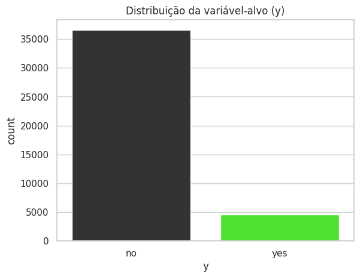

```python
# Custom colors
fluorescent_green = "#39FF14"
dark_gray = "#333333"

sns.countplot(
    data=df,
    x='y',
    hue='y',  # required by seaborn
    palette={'yes': fluorescent_green, 'no': dark_gray},
    legend=False  # hides duplicated legend
)

plt.title("Distribuição da variável-alvo (y)")
plt.show()
```

```python
categorical_cols = df.select_dtypes(include="object").columns.tolist()
numeric_cols = df.select_dtypes(include=['int64', 'float64']).columns.tolist()

print("Categóricas:", categorical_cols)
print("Numéricas:", numeric_cols)
```

```
Categóricas: ['job', 'marital', 'education', 'default', 'housing', 'loan', 'contact', 'month', 'day_of_week', 'poutcome', 'y']
Numéricas: ['age', 'duration', 'campaign', 'pdays', 'previous', 'emp.var.rate', 'cons.price.idx', 'cons.conf.idx', 'euribor3m', 'nr.employed']
```

```python
for col in df.columns:
    print(col, "→", df[col].nunique())
```

```
age → 78
job → 12
marital → 4
education → 8
default → 3
housing → 3
loan → 3
contact → 2
month → 10
day_of_week → 5
duration → 1544
campaign → 42
pdays → 27
previous → 8
poutcome → 3
emp.var.rate → 10
cons.price.idx → 26
cons.conf.idx → 26
euribor3m → 316
nr.employed → 11
y → 2
```

```python
unknown_cols = {col: (df[col] == 'unknown').sum()
                for col in df.columns if df[col].dtype == object}

unknown_cols
```

```
{'job': np.int64(330),
 'marital': np.int64(80),
 'education': np.int64(1731),
 'default': np.int64(8597),
 'housing': np.int64(990),
 'loan': np.int64(990),
 'contact': np.int64(0),
 'month': np.int64(0),
 'day_of_week': np.int64(0),
 'poutcome': np.int64(0),
 'y': np.int64(0)}
```

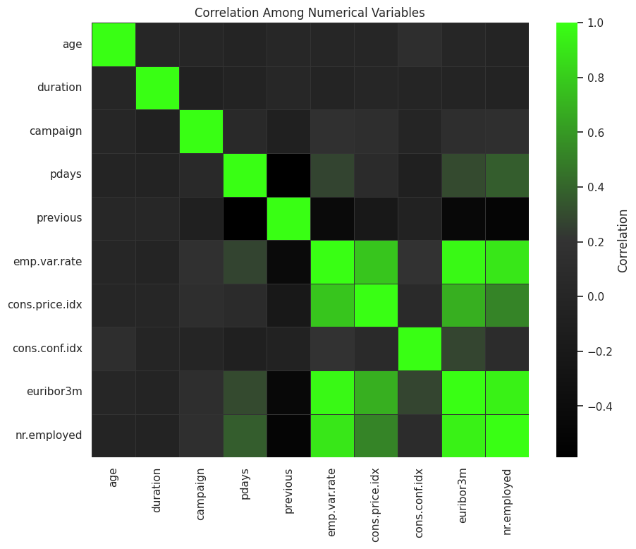

```python
from matplotlib.colors import LinearSegmentedColormap

# Custom colors
fluorescent_green = "#39FF14"
dark_gray = "#333333"
black = "#000000"

# Create custom colormap (black → dark gray → neon green)
custom_cmap = LinearSegmentedColormap.from_list(
    "custom_numeric_corr",
    [black, dark_gray, fluorescent_green]
)

# Select only numeric variables
numeric_df = df.select_dtypes(include=['int64', 'float64'])

# Plot heatmap
plt.figure(figsize=(10,8))
sns.heatmap(
    numeric_df.corr(),
    annot=False,
    cmap=custom_cmap,
    linewidths=0.5,
    linecolor=dark_gray,
    cbar_kws={'label': 'Correlation'}
)

plt.title("Correlation Among Numerical Variables")
plt.show()
```

## Financial Background

```python
def plot_acceptance_by_category(df, column):
    # Calcular percentagens (Acceptance Rate)
    data = df.groupby([column, 'y']).size().reset_index(name='count')

    # Transformar count em percentagem para cada categoria
    totals = data.groupby(column)['count'].transform('sum')
    data['percentage'] = (data['count'] / totals) * 100

    # Ordenar yes/no
    data['y'] = data['y'].map({'yes': 'Accepted', 'no': 'Not Accepted'})

    # Cores personalizadas
    colors = {
        'Accepted': '#39FF14',      # verde claro
        'Not Accepted': '#333333'   # cinzento claro
    }

    plt.figure(figsize=(7,5))
    ax = sns.barplot(
        data=data,
        x=column,
        y='percentage',
        hue='y',
        palette=colors
    )

    # Labels por cima das barras
    for p in ax.patches:
        height = p.get_height()
        ax.annotate(f'{height:.1f}%',
                    (p.get_x() + p.get_width() / 2, height),
                    ha='center', va='bottom', fontsize=10)

    plt.title(f"Acceptance Rate by {column.capitalize()}")
    plt.ylabel("Percentage (%)")
    plt.xlabel(column.capitalize())
    plt.legend(title="Outcome")
    plt.show()
```

### Gráficos Acceptance Rate by Loan

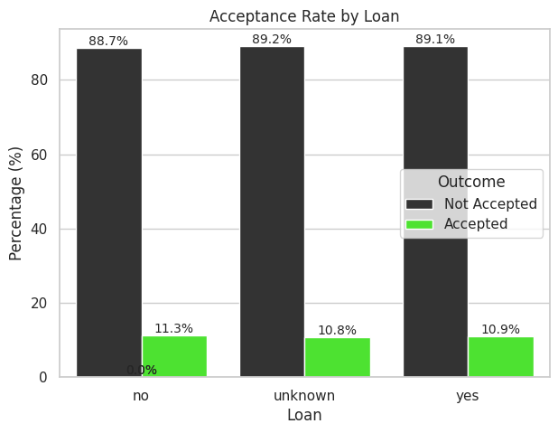

```python
plot_acceptance_by_category(df, 'loan')
```

### Gráficos Acceptance by Housing Loan

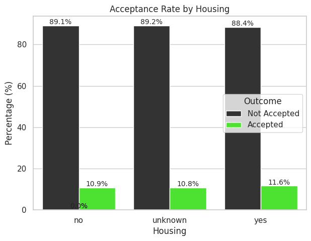

```python
plot_acceptance_by_category(df, 'housing')
```

### Gráficos Acceptance by Default Value

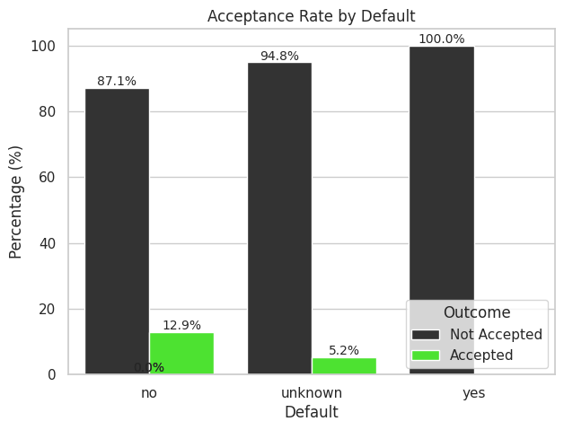

```python
plot_acceptance_by_category(df, 'default')
```

## Contact Information

```python
def plot_acceptance_by_category(df, column):
    data = df.groupby([column, 'y']).size().reset_index(name='count')
    totals = data.groupby(column)['count'].transform('sum')
    data['percentage'] = (data['count'] / totals) * 100
    data['y'] = data['y'].map({'yes': 'Accepted', 'no': 'Not Accepted'})

    colors = {
        'Accepted': '#39FF14',      # verde claro
        'Not Accepted': '#333333'
    }

    plt.figure(figsize=(8,5))
    ax = sns.barplot(
        data=data,
        x=column,
        y='percentage',
        hue='y',
        palette=colors
    )

    for p in ax.patches:
        height = p.get_height()
        ax.annotate(f'{height:.1f}%',
                    (p.get_x() + p.get_width() / 2, height),
                    ha='center', va='bottom', fontsize=10)

    plt.title(f"Acceptance Rate by {column.capitalize()}")
    plt.ylabel("Percentage (%)")
    plt.xlabel(column.capitalize())
    plt.legend(title="Outcome")
    plt.show()
```

### Gráfico Acceptance rate by Contact

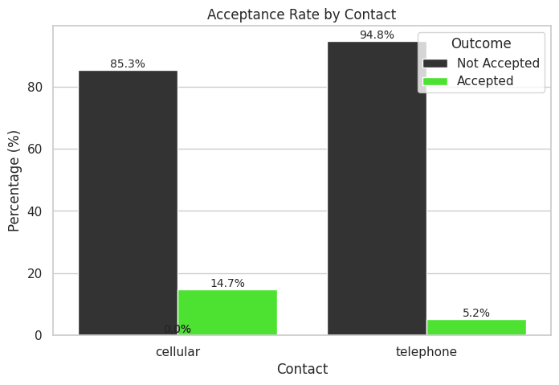

```python
plot_acceptance_by_category(df, "contact")
```

### Acceptance Rate by Month

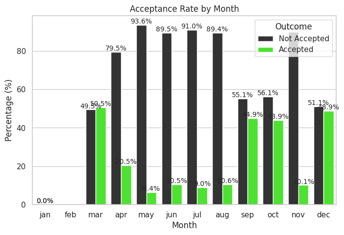

```python
# Ordem correta dos meses
month_order = [
    "jan", "feb", "mar", "apr", "may", "jun",
    "jul", "aug", "sep", "oct", "nov", "dec"
]

df['month'] = pd.Categorical(df['month'], categories=month_order, ordered=True)

# Plot
plot_acceptance_by_category(df, "month")
```

### Acceptance Rate by Day of the Week

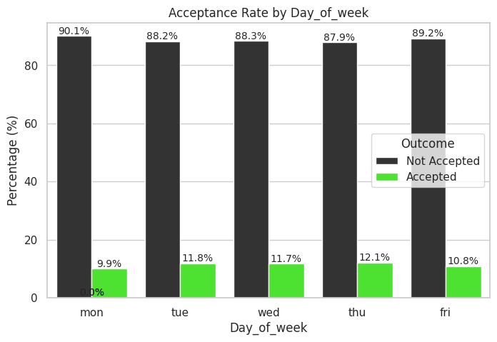

```python
# Ordem correta dos dias da semana
day_order = ["mon", "tue", "wed", "thu", "fri"]

df['day_of_week'] = pd.Categorical(df['day_of_week'], categories=day_order, ordered=True)

# Plot
plot_acceptance_by_category(df, "day_of_week")
```

### Acceptance Rate by Contact Duration

```python
# Criar bins (intervalos) de duração
bins = [0, 60, 120, 180, 240, 300, 600, 900, 1800]  # em segundos
labels = [
    "0-1 min", "1-2 min", "2-3 min", "3-4 min", "4-5 min",
    "5-10 min", "10-15 min", "15-30 min"
]

df["duration_group"] = pd.cut(df["duration"], bins=bins, labels=labels, include_lowest=True)
```

```python
def plot_acceptance_by_category(df, column):
    # Criar tabela com contagem yes/no por categoria
    data = df.groupby([column, 'y']).size().reset_index(name='count')
    totals = data.groupby(column)['count'].transform('sum')
    data['percentage'] = (data['count'] / totals) * 100
    data['y'] = data['y'].map({'yes': 'Accepted', 'no': 'Not Accepted'})

    colors = {
        'Accepted': '#39FF14',      # verde claro
        'Not Accepted': '#333333'
    }

    # --- FORÇA O TAMANHO DO GRÁFICO ---
    fig, ax = plt.subplots(figsize=(20,7))   # AQUI A WIDTH É REALMENTE 20

    sns.barplot(
        data=data,
        x=column,
        y='percentage',
        hue='y',
        palette=colors,
        ax=ax           # <- importante
    )

    # Data labels
    for p in ax.patches:
        height = p.get_height()
        ax.annotate(f'{height:.1f}%',
                    (p.get_x() + p.get_width()/2, height + 0.5),
                    ha='center', va='bottom', fontsize=10)

    ax.set_title(f"Acceptance Rate by {column.replace('_', ' ').title()}")
    ax.set_ylabel("Percentage (%)")
    ax.set_xlabel(column.replace('_', ' ').title())
    ax.set_xticklabels(ax.get_xticklabels(), rotation=45)

    plt.tight_layout()
    plt.show()
```

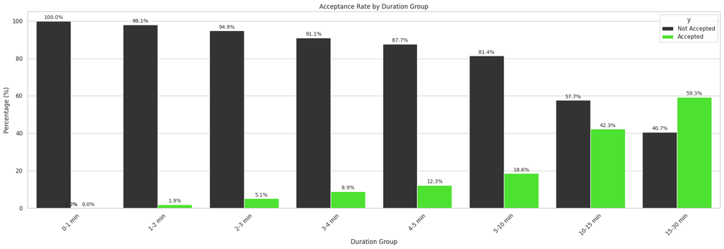

```python
plot_acceptance_by_category(df, "duration_group")
```

## Economic Features

```python
# Set style
sns.set(style="whitegrid", palette="viridis", font_scale=1.1)
```

Selecionar Economic Features

```python
# Select economic context variables

economic_cols = ['emp.var.rate', 'cons.price.idx', 'cons.conf.idx', 'euribor3m', 'nr.employed']
```

### Descriptive Statistics

```python
# Descriptive statistics

print("\nDescriptive statistics (economic variables):")
display(df[economic_cols].describe())
```

```
Descriptive statistics (economic variables):
```

|  | emp.var.rate | cons.price.idx | cons.conf.idx | euribor3m | nr.employed |
| --- | --- | --- | --- | --- | --- |
| count | 41188.000000 | 41188.000000 | 41188.000000 | 41188.000000 | 41188.000000 |
| mean | 0.081886 | 93.575664 | -40.502600 | 3.621291 | 5167.035911 |
| std | 1.570960 | 0.578840 | 4.628198 | 1.734447 | 72.251528 |
| min | -3.400000 | 92.201000 | -50.800000 | 0.634000 | 4963.600000 |
| 25% | -1.800000 | 93.075000 | -42.700000 | 1.344000 | 5099.100000 |
| 50% | 1.100000 | 93.749000 | -41.800000 | 4.857000 | 5191.000000 |
| 75% | 1.400000 | 93.994000 | -36.400000 | 4.961000 | 5228.100000 |
| max | 1.400000 | 94.767000 | -26.900000 | 5.045000 | 5228.100000 |

### Employment Variation Rate

Representa a taxa trimestral de variação do emprego em Portugal.

É um indicador de crescimento económico: valores positivos indicam aumento do emprego, valores negativos indicam recessão.

Um valor negativo pode sinalizar desaceleração económica, o que tende a reduzir a confiança do consumidor e a sua disposição para investir.

### Consumer Price Index

Mede a inflação — ou seja, a variação média dos preços dos bens e serviços.

Valores mais altos indicam inflação crescente, o que pode reduzir o poder de compra dos consumidores.

A inflação pode afetar as decisões de poupança:

Quando há inflação alta, as pessoas tendem a gastar mais agora (antes dos preços subirem ainda mais).

Quando é baixa, pode haver maior tendência para poupar.

👉 Interpretação: níveis moderados de inflação são geralmente favoráveis à subscrição de produtos financeiros.

### Consumer Confidence Index

Mede o grau de otimismo ou pessimismo dos consumidores sobre a economia e a sua situação financeira pessoal.

É geralmente negativo (em pontos) — valores mais altos (menos negativos) indicam maior confiança.

Quando a confiança é baixa, as pessoas evitam compromissos financeiros de longo prazo, como depósitos.

👉 Interpretação: quanto mais alto o valor (ou menos negativo), maior a propensão dos clientes a investir ou subscrever o depósito.

### Euribor 3 Months

É a taxa de juro média do mercado interbancário europeu para empréstimos de 3 meses.

Usada como referência para créditos, hipotecas e produtos financeiros.

Quando a Euribor está alta, o custo do crédito aumenta, o que pode desincentivar novos investimentos.

Quando está baixa, poupar torna-se menos atrativo (rendimentos baixos), mas pode incentivar outros tipos de investimento.

👉 Interpretação: normalmente, uma Euribor mais baixa está associada a períodos de estímulo económico.

### Number of Employees

Representa o número médio de pessoas empregadas em Portugal (em milhares).

É um indicador direto da saúde do mercado de trabalho.

Está fortemente correlacionado com emp.var.rate, pois ambos refletem a situação do emprego.

```python
# Import libraries
import pandas as pd

# Define economic variables
economic_cols = ['emp.var.rate', 'cons.price.idx', 'cons.conf.idx', 'euribor3m', 'nr.employed']

# Calculate means
overall_mean = df[economic_cols].mean().round(2)
yes_mean = df[df['y'] == 'yes'][economic_cols].mean().round(2)

# Create table dynamically without index column
summary = pd.DataFrame({
    'Variable': [
        'Employment Variation Rate',
        'Consumer Price Index',
        'Consumer Confidence Index',
        'Euribor 3 Month Rate',
        'Number of Employees'
    ][:len(economic_cols)],
    'Overall Mean': overall_mean.values,
    'Mean (y = yes)': yes_mean.values
})

# Custom colors
fluorescent_green = "#39FF14"
dark_gray = "#333333"

# Styled table with theme colors
styled_table = (
    summary.style
    .hide(axis="index")  # remove numbering
    .set_table_styles([
        {
            'selector': 'th',
            'props': [
                ('background-color', fluorescent_green),
                ('color', 'black'),
                ('font-weight', 'bold'),
                ('text-align', 'center'),
                ('padding', '8px')
            ]
        },
        {
            'selector': 'td',
            'props': [
                ('text-align', 'center'),
                ('padding', '6px'),
                ('color', 'black')
            ]
        },
        {
            'selector': 'tr:nth-child(even)',
            'props': [
                ('color', 'white')
            ]
        }
    ])
    .set_properties(**{'border': '1px solid #BDBDBD', 'width': '160px'})
)

styled_table
```

| Variable | Overall Mean | Mean (y = yes) |
| --- | --- | --- |
| Employment Variation Rate | 0.080000 | -1.230000 |
| Consumer Price Index | 93.580000 | 93.350000 |
| Consumer Confidence Index | -40.500000 | -39.790000 |
| Euribor 3 Month Rate | 3.620000 | 2.120000 |
| Number of Employees | 5167.040000 | 5095.120000 |

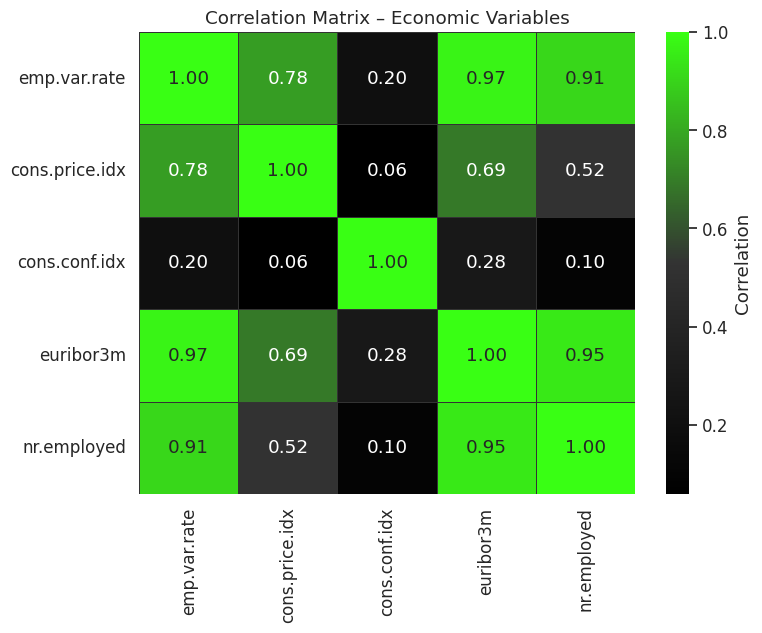

```python
# 3. Heatmap de correlação entre variáveis económicas
from matplotlib.colors import LinearSegmentedColormap

# Custom colors
fluorescent_green = "#39FF14"
dark_gray = "#333333"
black = "#000000"

# Create custom colormap (black → dark gray → neon green)
custom_cmap = LinearSegmentedColormap.from_list(
    "custom_heatmap",
    [black, dark_gray, fluorescent_green]
)

# Compute correlation matrix
corr = df[economic_cols].corr()

# Plot heatmap
plt.figure(figsize=(8, 6))
sns.heatmap(
    corr,
    annot=True,
    cmap=custom_cmap,
    fmt=".2f",
    linewidths=.5,
    linecolor=dark_gray,
    cbar_kws={'label': 'Correlation'}
)

plt.title("Correlation Matrix – Economic Variables")
plt.show()
```

## Demographic Variables

`age`

`job`

`marital`

`education`

### Age Segmentation and Visualization

```python
df['age'].describe()
```

|  | age |
| --- | --- |
| count | 41188.00000 |
| mean | 40.02406 |
| std | 10.42125 |
| min | 17.00000 |
| 25% | 32.00000 |
| 50% | 38.00000 |
| 75% | 47.00000 |
| max | 98.00000 |

**dtype:** float64

```python
# Create a function to classify age groups
def classify_age(age):
    if age <= 24:
        return "Youth"
    elif 25 <= age <= 39:
        return "Young Adult"
    elif 40 <= age <= 59:
        return "Adult"
    elif 60 <= age <= 64:
        return "Pre-Retirement"
    elif 65 <= age <= 74:
        return "Retired"
    else:
        return "Senior"

# Apply classification
df["Age Group"] = df["age"].apply(classify_age)

# Create the display table like the example
age_table = pd.DataFrame({
    "Age": ["<= 24", "25 – 39", "40 – 59", "60 – 64", "65 – 74", ">= 75"],
    "Age Group": ["Youth", "Young Adult", "Adult", "Pre-Retirement", "Retired", "Senior"]
})

# Style with fluorescent green header
fluorescent_green = "#39FF14"    # bright neon green

styled_table = (
    age_table.style
        .set_table_styles(
            [{
                "selector": "th",
                "props": [("background-color", fluorescent_green),
                          ("color", "black"),
                          ("font-weight", "bold")]
            }]
        )
        .set_properties(**{"text-align": "center"})
)

styled_table
```

|  | Age | Age Group |
| --- | --- | --- |
| 0 | <= 24 | Youth |
| 1 | 25 – 39 | Young Adult |
| 2 | 40 – 59 | Adult |
| 3 | 60 – 64 | Pre-Retirement |
| 4 | 65 – 74 | Retired |
| 5 | >= 75 | Senior |

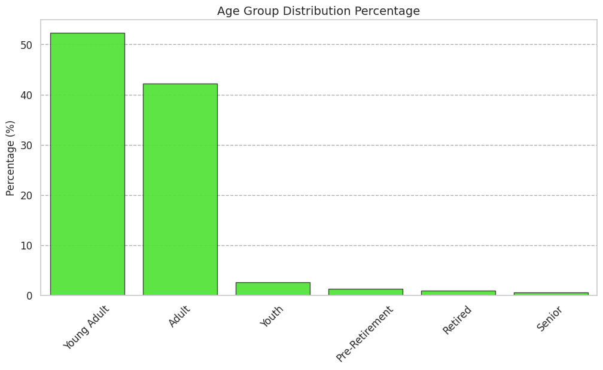

```python
# Custom colors
fluorescent_green = "#39FF14"
dark_gray = "#333333"

# Calculate percentage distribution of each age group
age_group_counts = df["Age Group"].value_counts(normalize=True) * 100

# Sort from largest to smallest
age_group_counts = age_group_counts.sort_values(ascending=False)

# Plot
plt.figure(figsize=(12, 6))
sns.barplot(
    x=age_group_counts.index,
    y=age_group_counts.values,
    color=fluorescent_green,       # neon green bars
    edgecolor=dark_gray,           # dark gray border
    alpha=0.9
)

plt.title("Age Group Distribution Percentage", fontsize=14)
plt.xlabel("")
plt.ylabel("Percentage (%)", fontsize=12)
plt.xticks(rotation=45)
plt.grid(axis="y", linestyle="--", alpha=0.4, color=dark_gray)

plt.show()
```

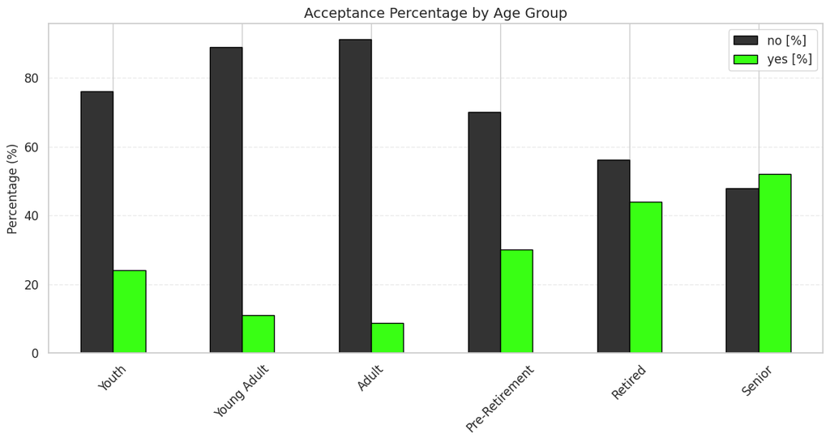

```python
# Custom colors
fluorescent_green = "#39FF14"
dark_gray = "#333333"

# Calculate acceptance (%) by age group
acceptance_counts = (
    df.groupby(["Age Group", "y"])["y"]
      .count()
      .unstack(fill_value=0)
)

# Convert to percentages
acceptance_percent = acceptance_counts.div(acceptance_counts.sum(axis=1), axis=0) * 100

# Ensure both columns exist (yes/no)
if "yes" not in acceptance_percent.columns:
    acceptance_percent["yes"] = 0
if "no" not in acceptance_percent.columns:
    acceptance_percent["no"] = 0

# Sort by Age Group order
acceptance_percent = acceptance_percent.loc[
    ["Youth", "Young Adult", "Adult", "Pre-Retirement", "Retired", "Senior"]
]

# Plot
plt.figure(figsize=(14, 6))

acceptance_percent.plot(
    kind="bar",
    figsize=(14, 6),
    color={"no": dark_gray, "yes": fluorescent_green},
    edgecolor="black"
)

plt.title("Acceptance Percentage by Age Group", fontsize=14)
plt.ylabel("Percentage (%)", fontsize=12)
plt.xlabel("")
plt.xticks(rotation=45)
plt.grid(axis="y", linestyle="--", alpha=0.4)

plt.legend(title="", labels=["no [%]", "yes [%]"])

plt.show()
```

### Job Distribuition and Visualization

```python
df['job'].value_counts()
```

| job | count |
| --- | --- |
| admin. | 10422 |
| blue-collar | 9254 |
| technician | 6743 |
| services | 3969 |
| management | 2924 |
| retired | 1720 |
| entrepreneur | 1456 |
| self-employed | 1421 |
| housemaid | 1060 |
| unemployed | 1014 |
| student | 875 |
| unknown | 330 |

**dtype:** int64

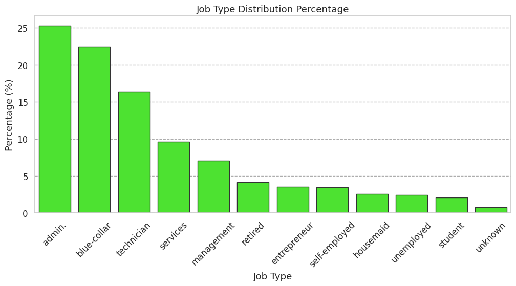

```python
# Calculate percentage distribution
job_percent = (df['job'].value_counts(normalize=True) * 100).sort_values(ascending=False)

# Plot
plt.figure(figsize=(12, 5))

sns.barplot(
    x=job_percent.index,
    y=job_percent.values,
    color=fluorescent_green,
    edgecolor=dark_gray
)

plt.title("Job Type Distribution Percentage")
plt.xlabel("Job Type")
plt.ylabel("Percentage (%)")
plt.xticks(rotation=45)
plt.grid(axis="y", linestyle="--", alpha=0.4, color=dark_gray)

plt.show()
```

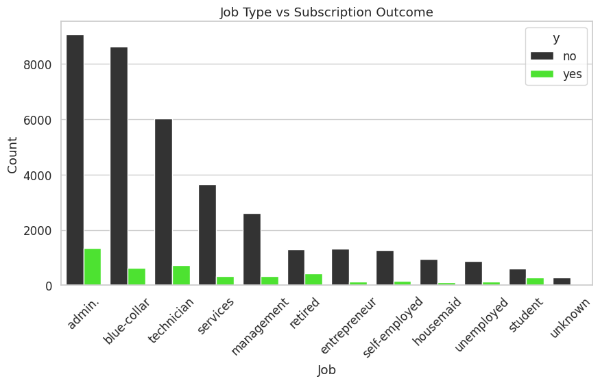

```python
# --- JOB ---

plt.figure(figsize=(10,5))

sns.countplot(
    data=df,
    x='job',
    hue='y',
    order=df['job'].value_counts().index,
    palette={'yes': fluorescent_green, 'no': dark_gray}
)

plt.xticks(rotation=45)
plt.title("Job Type vs Subscription Outcome")
plt.xlabel("Job")
plt.ylabel("Count")
plt.show()
```

### Marital Distribution and Visualization

```python
df['marital'].value_counts()
```

| marital | count |
| --- | --- |
| married | 24928 |
| single | 11568 |
| divorced | 4612 |
| unknown | 80 |

**dtype:** int64

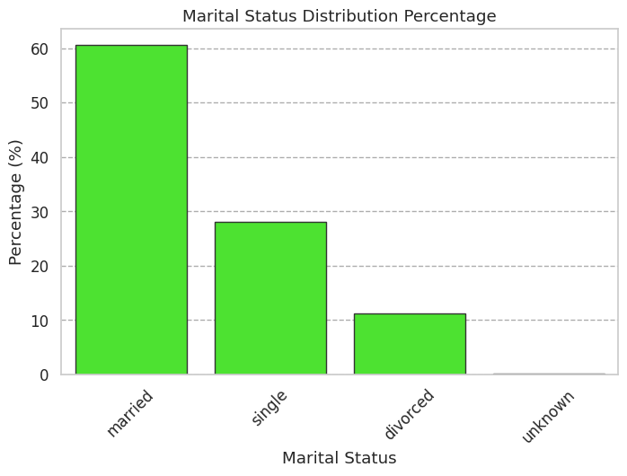

```python
# Calculate percentage distribution
marital_percent = (df['marital'].value_counts(normalize=True) * 100).sort_values(ascending=False)

# Plot
plt.figure(figsize=(8, 5))

sns.barplot(
    x=marital_percent.index,
    y=marital_percent.values,
    color=fluorescent_green,
    edgecolor=dark_gray
)

plt.title("Marital Status Distribution Percentage")
plt.xlabel("Marital Status")
plt.ylabel("Percentage (%)")
plt.xticks(rotation=45)
plt.grid(axis="y", linestyle="--", alpha=0.4, color=dark_gray)

plt.show()
```

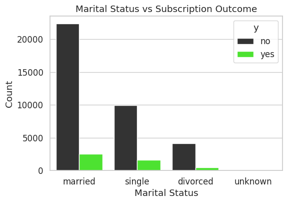

```python
# --- MARITAL STATUS ---

plt.figure(figsize=(6,4))

sns.countplot(
    data=df,
    x='marital',
    hue='y',
    palette={'yes': fluorescent_green, 'no': dark_gray}
)

plt.title("Marital Status vs Subscription Outcome")
plt.xlabel("Marital Status")
plt.ylabel("Count")
plt.show()
```

### Education Distribuition and Visualizations

```python
df['education'].value_counts()
```

| education | count |
| --- | --- |
| university.degree | 12168 |
| high.school | 9515 |
| basic.9y | 6045 |
| professional.course | 5243 |
| basic.4y | 4176 |
| basic.6y | 2292 |
| unknown | 1731 |
| illiterate | 18 |

**dtype:** int64

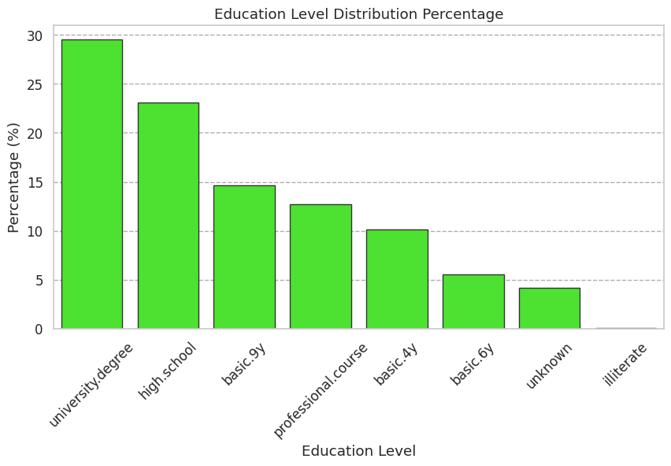

```python
# Calculate percentage distribution
education_percent = (df['education'].value_counts(normalize=True) * 100).sort_values(ascending=False)

# Plot
plt.figure(figsize=(10, 5))

sns.barplot(
    x=education_percent.index,
    y=education_percent.values,
    color=fluorescent_green,
    edgecolor=dark_gray
)

plt.title("Education Level Distribution Percentage")
plt.xlabel("Education Level")
plt.ylabel("Percentage (%)")
plt.xticks(rotation=45)
plt.grid(axis="y", linestyle="--", alpha=0.4, color=dark_gray)

plt.show()
```

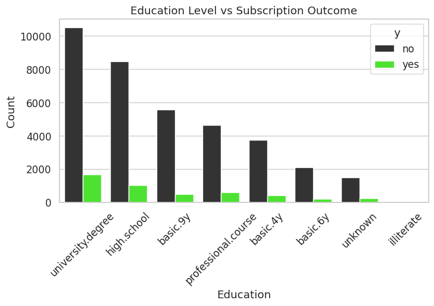

```python
# --- EDUCATION ---

plt.figure(figsize=(8,4))

sns.countplot(
    data=df,
    x='education',
    hue='y',
    order=df['education'].value_counts().index,
    palette={'yes': fluorescent_green, 'no': dark_gray}
)

plt.xticks(rotation=45)
plt.title("Education Level vs Subscription Outcome")
plt.xlabel("Education")
plt.ylabel("Count")
plt.show()
```

# Preprocessing

```python
# Basic inspection

df_pp = df.copy()

df_pp.info()
df_pp.head()
```

```
<class 'pandas.core.frame.DataFrame'>
RangeIndex: 41188 entries, 0 to 41187
Data columns (total 23 columns):
 #   Column          Non-Null Count  Dtype
---  ------          --------------  -----
 0   age             41188 non-null  int64
 1   job             41188 non-null  object
 2   marital         41188 non-null  object
 3   education       41188 non-null  object
 4   default         41188 non-null  object
 5   housing         41188 non-null  object
 6   loan            41188 non-null  object
 7   contact         41188 non-null  object
 8   month           41188 non-null  category
 9   day_of_week     41188 non-null  category
 10  duration        41188 non-null  int64
 11  campaign        41188 non-null  int64
 12  pdays           41188 non-null  int64
 13  previous        41188 non-null  int64
 14  poutcome        41188 non-null  object
 15  emp.var.rate    41188 non-null  float64
 16  cons.price.idx  41188 non-null  float64
 17  cons.conf.idx   41188 non-null  float64
 18  euribor3m       41188 non-null  float64
 19  nr.employed     41188 non-null  float64
 20  y               41188 non-null  object
 21  duration_group  41087 non-null  category
 22  Age Group       41188 non-null  object
dtypes: category(3), float64(5), int64(5), object(10)
memory usage: 6.4+ MB
```

|  | age | job | marital | education | default | housing | loan | contact | month | day_of_week | duration | campaign | pdays | previous | poutcome | emp.var.rate | cons.price.idx | cons.conf.idx | euribor3m | nr.employed | y | duration_group | Age Group |
| --- | --- | --- | --- | --- | --- | --- | --- | --- | --- | --- | --- | --- | --- | --- | --- | --- | --- | --- | --- | --- | --- | --- | --- |
| 0 | 56 | housemaid | married | basic.4y | no | no | no | telephone | may | mon | 261 | 1 | 999 | 0 | nonexistent | 1.1 | 93.994 | -36.4 | 4.857 | 5191.0 | no | 4-5 min | Adult |
| 1 | 57 | services | married | high.school | unknown | no | no | telephone | may | mon | 149 | 1 | 999 | 0 | nonexistent | 1.1 | 93.994 | -36.4 | 4.857 | 5191.0 | no | 2-3 min | Adult |
| 2 | 37 | services | married | high.school | no | yes | no | telephone | may | mon | 226 | 1 | 999 | 0 | nonexistent | 1.1 | 93.994 | -36.4 | 4.857 | 5191.0 | no | 3-4 min | Young Adult |
| 3 | 40 | admin. | married | basic.6y | no | no | no | telephone | may | mon | 151 | 1 | 999 | 0 | nonexistent | 1.1 | 93.994 | -36.4 | 4.857 | 5191.0 | no | 2-3 min | Adult |
| 4 | 56 | services | married | high.school | no | no | yes | telephone | may | mon | 307 | 1 | 999 | 0 | nonexistent | 1.1 | 93.994 | -36.4 | 4.857 | 5191.0 | no | 5-10 min | Adult |

## Missing Values

### Analise e Visualização Missing Values

```python
# Replace 'unknown' with NaN for easier processing
df_pp.replace("unknown", np.nan, inplace=True)

# Check missing values
df_pp.isna().sum()
```

|  | 0 |
| --- | --- |
| age | 0 |
| job | 330 |
| marital | 80 |
| education | 1731 |
| default | 8597 |
| housing | 990 |
| loan | 990 |
| contact | 0 |
| month | 0 |
| day_of_week | 0 |
| duration | 0 |
| campaign | 0 |
| pdays | 0 |
| previous | 0 |
| poutcome | 0 |
| emp.var.rate | 0 |
| cons.price.idx | 0 |
| cons.conf.idx | 0 |
| euribor3m | 0 |
| nr.employed | 0 |
| y | 0 |
| duration_group | 101 |
| Age Group | 0 |

**dtype:** int64

```python
#Missing values percentage
missing_percentage = (df_pp.isna().mean() * 100).sort_values(ascending=False)
missing_percentage
```

|  | 0 |
| --- | --- |
| default | 20.872584 |
| education | 4.202680 |
| housing | 2.403613 |
| loan | 2.403613 |
| job | 0.801204 |
| duration_group | 0.245217 |
| marital | 0.194231 |
| age | 0.000000 |
| contact | 0.000000 |
| day_of_week | 0.000000 |
| month | 0.000000 |
| campaign | 0.000000 |
| pdays | 0.000000 |
| previous | 0.000000 |
| duration | 0.000000 |
| poutcome | 0.000000 |
| emp.var.rate | 0.000000 |
| cons.conf.idx | 0.000000 |
| cons.price.idx | 0.000000 |
| euribor3m | 0.000000 |
| nr.employed | 0.000000 |
| y | 0.000000 |
| Age Group | 0.000000 |

**dtype:** float64

Existem alguns missing values.

### Categorical Variables - Mode

```python
categorical_cols = df_pp.select_dtypes(include=["object", "category"]).columns

for col in categorical_cols:
    df_pp[col] = df_pp[col].fillna(df_pp[col].mode()[0])
```

### Numerical Variables - Median

```python
numerical_cols = df_pp.select_dtypes(include=np.number).columns

for col in numerical_cols:
    df_pp[col].fillna(df_pp[col].median(), inplace=True)
```

### Confirm Missing Values

```python
df_pp.isna().sum()
```

|  | 0 |
| --- | --- |
| age | 0 |
| job | 0 |
| marital | 0 |
| education | 0 |
| default | 0 |
| housing | 0 |
| loan | 0 |
| contact | 0 |
| month | 0 |
| day_of_week | 0 |
| duration | 0 |
| campaign | 0 |
| pdays | 0 |
| previous | 0 |
| poutcome | 0 |
| emp.var.rate | 0 |
| cons.price.idx | 0 |
| cons.conf.idx | 0 |
| euribor3m | 0 |
| nr.employed | 0 |
| y | 0 |
| duration_group | 0 |
| Age Group | 0 |

**dtype:** int64

## Outliers

```python
# Select numerical columns from df_pp
numeric_cols = df_pp.select_dtypes(include=['int64', 'float64']).columns

numeric_cols
```

```
Index(['age', 'duration', 'campaign', 'pdays', 'previous', 'emp.var.rate',
       'cons.price.idx', 'cons.conf.idx', 'euribor3m', 'nr.employed'],
      dtype='object')
```

### Winsorizer function method

substitui outliers acima do 99º percentil pelo valor no 99º percentil

substitui outliers abaixo do 1º percentil pelo valor no 1º percentil

mantém o tamanho da amostra

preserva padrões dos dados

```python
import numpy as np

def winsorize_column(series, lower_q=0.01, upper_q=0.99):
    lower_bound = series.quantile(lower_q)
    upper_bound = series.quantile(upper_q)
    return np.clip(series, lower_bound, upper_bound)
```

Apply Winsorizer

```python
for col in numeric_cols:
    df_pp[col] = winsorize_column(df_pp[col], lower_q=0.01, upper_q=0.99)
```

```python
col = "age"

print("Before winsorization:")
print(df[col].describe())

print("\nAfter winsorization:")
print(df_pp[col].describe())
```

```
Before winsorization:
count    41188.00000
mean        40.02406
std         10.42125
min         17.00000
25%         32.00000
50%         38.00000
75%         47.00000
max         98.00000
Name: age, dtype: float64

After winsorization:
count    41188.000000
mean        39.976644
std         10.138262
min         23.000000
25%         32.000000
50%         38.000000
75%         47.000000
max         71.000000
Name: age, dtype: float64
```

# Encoding

```python
df_pp.head()
```

|  | age | job | marital | education | default | housing | loan | contact | month | day_of_week | duration | campaign | pdays | previous | poutcome | emp.var.rate | cons.price.idx | cons.conf.idx | euribor3m | nr.employed | y | duration_group | Age Group |
| --- | --- | --- | --- | --- | --- | --- | --- | --- | --- | --- | --- | --- | --- | --- | --- | --- | --- | --- | --- | --- | --- | --- | --- |
| 0 | 56 | housemaid | married | basic.4y | no | no | no | telephone | may | mon | 261.0 | 1 | 999 | 0 | nonexistent | 1.1 | 93.994 | -36.4 | 4.857 | 5191.0 | no | 4-5 min | Adult |
| 1 | 57 | services | married | high.school | no | no | no | telephone | may | mon | 149.0 | 1 | 999 | 0 | nonexistent | 1.1 | 93.994 | -36.4 | 4.857 | 5191.0 | no | 2-3 min | Adult |
| 2 | 37 | services | married | high.school | no | yes | no | telephone | may | mon | 226.0 | 1 | 999 | 0 | nonexistent | 1.1 | 93.994 | -36.4 | 4.857 | 5191.0 | no | 3-4 min | Young Adult |
| 3 | 40 | admin. | married | basic.6y | no | no | no | telephone | may | mon | 151.0 | 1 | 999 | 0 | nonexistent | 1.1 | 93.994 | -36.4 | 4.857 | 5191.0 | no | 2-3 min | Adult |
| 4 | 56 | services | married | high.school | no | no | yes | telephone | may | mon | 307.0 | 1 | 999 | 0 | nonexistent | 1.1 | 93.994 | -36.4 | 4.857 | 5191.0 | no | 5-10 min | Adult |

## One-hot encoding

```python
df_pp['job'].value_counts()
```

| job | count |
| --- | --- |
| admin. | 10752 |
| blue-collar | 9254 |
| technician | 6743 |
| services | 3969 |
| management | 2924 |
| retired | 1720 |
| entrepreneur | 1456 |
| self-employed | 1421 |
| housemaid | 1060 |
| unemployed | 1014 |
| student | 875 |

**dtype:** int64

```python
# apply one hot encoding on variable job

df_pp = pd.get_dummies(df_pp, columns=['job'], drop_first=True)
df_pp.head()
```

|  | age | marital | education | default | housing | loan | contact | month | day_of_week | duration | campaign | pdays | previous | poutcome | emp.var.rate | cons.price.idx | cons.conf.idx | euribor3m | nr.employed | y | duration_group | Age Group | job_blue-collar | job_entrepreneur | job_housemaid | job_management | job_retired | job_self-employed | job_services | … |
| --- | --- | --- | --- | --- | --- | --- | --- | --- | --- | --- | --- | --- | --- | --- | --- | --- | --- | --- | --- | --- | --- | --- | --- | --- | --- | --- | --- | --- | --- | --- |
| 0 | 56 | married | basic.4y | no | no | no | telephone | may | mon | 261.0 | 1 | 999 | 0 | nonexistent | 1.1 | 93.994 | -36.4 | 4.857 | 5191.0 | no | 4-5 min | Adult | False | False | True | False | False | False | False | … |
| 1 | 57 | married | high.school | no | no | no | telephone | may | mon | 149.0 | 1 | 999 | 0 | nonexistent | 1.1 | 93.994 | -36.4 | 4.857 | 5191.0 | no | 2-3 min | Adult | False | False | False | False | False | False | True | … |
| 2 | 37 | married | high.school | no | yes | no | telephone | may | mon | 226.0 | 1 | 999 | 0 | nonexistent | 1.1 | 93.994 | -36.4 | 4.857 | 5191.0 | no | 3-4 min | Young Adult | False | False | False | False | False | False | True | … |
| 3 | 40 | married | basic.6y | no | no | no | telephone | may | mon | 151.0 | 1 | 999 | 0 | nonexistent | 1.1 | 93.994 | -36.4 | 4.857 | 5191.0 | no | 2-3 min | Adult | False | False | False | False | False | False | False | … |
| 4 | 56 | married | high.school | no | no | yes | telephone | may | mon | 307.0 | 1 | 999 | 0 | nonexistent | 1.1 | 93.994 | -36.4 | 4.857 | 5191.0 | no | 5-10 min | Adult | False | False | False | False | False | False | True | … |

### Marital

```python
df_pp['marital'].value_counts()
```

| marital | count |
| --- | --- |
| married | 25008 |
| single | 11568 |
| divorced | 4612 |

**dtype:** int64

```python
# apply one hot encoding on variable marital

df_pp = pd.get_dummies(df_pp, columns=['marital'], drop_first=True)
df_pp.head()
```

|  | age | education | default | housing | loan | contact | month | day_of_week | duration | campaign | pdays | previous | poutcome | emp.var.rate | cons.price.idx | cons.conf.idx | euribor3m | nr.employed | y | duration_group | Age Group | job_blue-collar | job_entrepreneur | job_housemaid | job_management | job_retired | job_self-employed | job_services | job_student | … |
| --- | --- | --- | --- | --- | --- | --- | --- | --- | --- | --- | --- | --- | --- | --- | --- | --- | --- | --- | --- | --- | --- | --- | --- | --- | --- | --- | --- | --- | --- | --- |
| 0 | 56 | basic.4y | no | no | no | telephone | may | mon | 261.0 | 1 | 999 | 0 | nonexistent | 1.1 | 93.994 | -36.4 | 4.857 | 5191.0 | no | 4-5 min | Adult | False | False | True | False | False | False | False | False | … |
| 1 | 57 | high.school | no | no | no | telephone | may | mon | 149.0 | 1 | 999 | 0 | nonexistent | 1.1 | 93.994 | -36.4 | 4.857 | 5191.0 | no | 2-3 min | Adult | False | False | False | False | False | False | True | False | … |
| 2 | 37 | high.school | no | yes | no | telephone | may | mon | 226.0 | 1 | 999 | 0 | nonexistent | 1.1 | 93.994 | -36.4 | 4.857 | 5191.0 | no | 3-4 min | Young Adult | False | False | False | False | False | False | True | False | … |
| 3 | 40 | basic.6y | no | no | no | telephone | may | mon | 151.0 | 1 | 999 | 0 | nonexistent | 1.1 | 93.994 | -36.4 | 4.857 | 5191.0 | no | 2-3 min | Adult | False | False | False | False | False | False | False | False | … |
| 4 | 56 | high.school | no | no | yes | telephone | may | mon | 307.0 | 1 | 999 | 0 | nonexistent | 1.1 | 93.994 | -36.4 | 4.857 | 5191.0 | no | 5-10 min | Adult | False | False | False | False | False | False | True | False | … |

### Contact

```python
df_pp['contact'].value_counts()
```

| contact | count |
| --- | --- |
| cellular | 26144 |
| telephone | 15044 |

**dtype:** int64

```python
# apply one hot encoding on variable contact

df_pp = pd.get_dummies(df_pp, columns=['contact'], drop_first=True)
df_pp.head()
```

|  | age | education | default | housing | loan | month | day_of_week | duration | campaign | pdays | previous | poutcome | emp.var.rate | cons.price.idx | cons.conf.idx | euribor3m | nr.employed | y | duration_group | Age Group | job_blue-collar | job_entrepreneur | job_housemaid | job_management | job_retired | job_self-employed | job_services | job_student | job_technician | … |
| --- | --- | --- | --- | --- | --- | --- | --- | --- | --- | --- | --- | --- | --- | --- | --- | --- | --- | --- | --- | --- | --- | --- | --- | --- | --- | --- | --- | --- | --- | --- |
| 0 | 56 | basic.4y | no | no | no | may | mon | 261.0 | 1 | 999 | 0 | nonexistent | 1.1 | 93.994 | -36.4 | 4.857 | 5191.0 | no | 4-5 min | Adult | False | False | True | False | False | False | False | False | False | … |
| 1 | 57 | high.school | no | no | no | may | mon | 149.0 | 1 | 999 | 0 | nonexistent | 1.1 | 93.994 | -36.4 | 4.857 | 5191.0 | no | 2-3 min | Adult | False | False | False | False | False | False | True | False | False | … |
| 2 | 37 | high.school | no | yes | no | may | mon | 226.0 | 1 | 999 | 0 | nonexistent | 1.1 | 93.994 | -36.4 | 4.857 | 5191.0 | no | 3-4 min | Young Adult | False | False | False | False | False | False | True | False | False | … |
| 3 | 40 | basic.6y | no | no | no | may | mon | 151.0 | 1 | 999 | 0 | nonexistent | 1.1 | 93.994 | -36.4 | 4.857 | 5191.0 | no | 2-3 min | Adult | False | False | False | False | False | False | False | False | False | … |
| 4 | 56 | high.school | no | no | yes | may | mon | 307.0 | 1 | 999 | 0 | nonexistent | 1.1 | 93.994 | -36.4 | 4.857 | 5191.0 | no | 5-10 min | Adult | False | False | False | False | False | False | True | False | False | … |

### Poutcome

Esta variavel indica o sucesso da campanha anterior

```python
df_pp['poutcome'].value_counts()
```

| poutcome | count |
| --- | --- |
| nonexistent | 35563 |
| failure | 4252 |
| success | 1373 |

**dtype:** int64

```python
#apply one hot encoding to variable poutcome
df_pp = pd.get_dummies(df_pp, columns=['poutcome'], drop_first=True)
df_pp.head()
```

|  | age | education | default | housing | loan | month | day_of_week | duration | campaign | pdays | previous | emp.var.rate | cons.price.idx | cons.conf.idx | euribor3m | nr.employed | y | duration_group | Age Group | job_blue-collar | job_entrepreneur | job_housemaid | job_management | job_retired | job_self-employed | job_services | job_student | job_technician | job_unemployed | … |
| --- | --- | --- | --- | --- | --- | --- | --- | --- | --- | --- | --- | --- | --- | --- | --- | --- | --- | --- | --- | --- | --- | --- | --- | --- | --- | --- | --- | --- | --- | --- |
| 0 | 56 | basic.4y | no | no | no | may | mon | 261.0 | 1 | 999 | 0 | 1.1 | 93.994 | -36.4 | 4.857 | 5191.0 | no | 4-5 min | Adult | False | False | True | False | False | False | False | False | False | False | … |
| 1 | 57 | high.school | no | no | no | may | mon | 149.0 | 1 | 999 | 0 | 1.1 | 93.994 | -36.4 | 4.857 | 5191.0 | no | 2-3 min | Adult | False | False | False | False | False | False | True | False | False | False | … |
| 2 | 37 | high.school | no | yes | no | may | mon | 226.0 | 1 | 999 | 0 | 1.1 | 93.994 | -36.4 | 4.857 | 5191.0 | no | 3-4 min | Young Adult | False | False | False | False | False | False | True | False | False | False | … |
| 3 | 40 | basic.6y | no | no | no | may | mon | 151.0 | 1 | 999 | 0 | 1.1 | 93.994 | -36.4 | 4.857 | 5191.0 | no | 2-3 min | Adult | False | False | False | False | False | False | False | False | False | False | … |
| 4 | 56 | high.school | no | no | yes | may | mon | 307.0 | 1 | 999 | 0 | 1.1 | 93.994 | -36.4 | 4.857 | 5191.0 | no | 5-10 min | Adult | False | False | False | False | False | False | True | False | False | False | … |

## Binary encoding

### Loan

```python
df_pp['loan'].value_counts()
```

| loan | count |
| --- | --- |
| no | 34940 |
| yes | 6248 |

**dtype:** int64

```python
# apply binary encoding on variable loan

df_pp['loan'] = df_pp['loan'].map({'yes': 1, 'no': 0})
df_pp
```

|  | age | education | default | housing | loan | month | day_of_week | duration | campaign | pdays | previous | emp.var.rate | cons.price.idx | cons.conf.idx | euribor3m | nr.employed | y | duration_group | Age Group | job_blue-collar | job_entrepreneur | job_housemaid | job_management | job_retired | job_self-employed | job_services | job_student | job_technician | job_unemployed | … |
| --- | --- | --- | --- | --- | --- | --- | --- | --- | --- | --- | --- | --- | --- | --- | --- | --- | --- | --- | --- | --- | --- | --- | --- | --- | --- | --- | --- | --- | --- | --- |
| 0 | 56 | basic.4y | no | no | 0 | may | mon | 261.0 | 1 | 999 | 0 | 1.1 | 93.994 | -36.4 | 4.857 | 5191.0 | no | 4-5 min | Adult | False | False | True | False | False | False | False | False | False | False | … |
| 1 | 57 | high.school | no | no | 0 | may | mon | 149.0 | 1 | 999 | 0 | 1.1 | 93.994 | -36.4 | 4.857 | 5191.0 | no | 2-3 min | Adult | False | False | False | False | False | False | True | False | False | False | … |
| 2 | 37 | high.school | no | yes | 0 | may | mon | 226.0 | 1 | 999 | 0 | 1.1 | 93.994 | -36.4 | 4.857 | 5191.0 | no | 3-4 min | Young Adult | False | False | False | False | False | False | True | False | False | False | … |
| 3 | 40 | basic.6y | no | no | 0 | may | mon | 151.0 | 1 | 999 | 0 | 1.1 | 93.994 | -36.4 | 4.857 | 5191.0 | no | 2-3 min | Adult | False | False | False | False | False | False | False | False | False | False | … |
| 4 | 56 | high.school | no | no | 1 | may | mon | 307.0 | 1 | 999 | 0 | 1.1 | 93.994 | -36.4 | 4.857 | 5191.0 | no | 5-10 min | Adult | False | False | False | False | False | False | True | False | False | False | … |
| ... | ... | ... | ... | ... | ... | ... | ... | ... | ... | ... | ... | ... | ... | ... | ... | ... | ... | ... | ... | ... | ... | ... | ... | ... | ... | ... | ... | ... | ... | … |
| 41183 | 71 | professional.course | no | yes | 0 | nov | fri | 334.0 | 1 | 999 | 0 | -1.1 | 94.465 | -49.5 | 1.028 | 4963.6 | yes | 5-10 min | Retired | False | False | False | False | True | False | False | False | False | False | … |
| 41184 | 46 | professional.course | no | no | 0 | nov | fri | 383.0 | 1 | 999 | 0 | -1.1 | 94.465 | -49.5 | 1.028 | 4963.6 | no | 5-10 min | Adult | True | False | False | False | False | False | False | False | False | False | … |
| 41185 | 56 | university.degree | no | yes | 0 | nov | fri | 189.0 | 2 | 999 | 0 | -1.1 | 94.465 | -49.5 | 1.028 | 4963.6 | no | 3-4 min | Adult | False | False | False | False | True | False | False | False | False | False | … |
| 41186 | 44 | professional.course | no | no | 0 | nov | fri | 442.0 | 1 | 999 | 0 | -1.1 | 94.465 | -49.5 | 1.028 | 4963.6 | yes | 5-10 min | Adult | False | False | False | False | False | False | False | False | True | False | … |
| 41187 | 71 | professional.course | no | yes | 0 | nov | fri | 239.0 | 3 | 999 | 1 | -1.1 | 94.465 | -49.5 | 1.028 | 4963.6 | no | 3-4 min | Retired | False | False | False | False | True | False | False | False | False | False | … |

41188 rows × 34 columns

### Housing

```python
df_pp['housing'].value_counts()
```

| housing | count |
| --- | --- |
| yes | 22566 |
| no | 18622 |

**dtype:** int64

```python
# apply binary encoding on variable housing

df_pp['housing'] = df_pp['housing'].map({'yes': 1, 'no': 0})
df_pp
```

|  | age | education | default | housing | loan | month | day_of_week | duration | campaign | pdays | previous | emp.var.rate | cons.price.idx | cons.conf.idx | euribor3m | nr.employed | y | duration_group | Age Group | job_blue-collar | job_entrepreneur | job_housemaid | job_management | job_retired | job_self-employed | job_services | job_student | job_technician | job_unemployed | … |
| --- | --- | --- | --- | --- | --- | --- | --- | --- | --- | --- | --- | --- | --- | --- | --- | --- | --- | --- | --- | --- | --- | --- | --- | --- | --- | --- | --- | --- | --- | --- |
| 0 | 56 | basic.4y | no | 0 | 0 | may | mon | 261.0 | 1 | 999 | 0 | 1.1 | 93.994 | -36.4 | 4.857 | 5191.0 | no | 4-5 min | Adult | False | False | True | False | False | False | False | False | False | False | … |
| 1 | 57 | high.school | no | 0 | 0 | may | mon | 149.0 | 1 | 999 | 0 | 1.1 | 93.994 | -36.4 | 4.857 | 5191.0 | no | 2-3 min | Adult | False | False | False | False | False | False | True | False | False | False | … |
| 2 | 37 | high.school | no | 1 | 0 | may | mon | 226.0 | 1 | 999 | 0 | 1.1 | 93.994 | -36.4 | 4.857 | 5191.0 | no | 3-4 min | Young Adult | False | False | False | False | False | False | True | False | False | False | … |
| 3 | 40 | basic.6y | no | 0 | 0 | may | mon | 151.0 | 1 | 999 | 0 | 1.1 | 93.994 | -36.4 | 4.857 | 5191.0 | no | 2-3 min | Adult | False | False | False | False | False | False | False | False | False | False | … |
| 4 | 56 | high.school | no | 0 | 1 | may | mon | 307.0 | 1 | 999 | 0 | 1.1 | 93.994 | -36.4 | 4.857 | 5191.0 | no | 5-10 min | Adult | False | False | False | False | False | False | True | False | False | False | … |
| ... | ... | ... | ... | ... | ... | ... | ... | ... | ... | ... | ... | ... | ... | ... | ... | ... | ... | ... | ... | ... | ... | ... | ... | ... | ... | ... | ... | ... | ... | … |
| 41183 | 71 | professional.course | no | 1 | 0 | nov | fri | 334.0 | 1 | 999 | 0 | -1.1 | 94.465 | -49.5 | 1.028 | 4963.6 | yes | 5-10 min | Retired | False | False | False | False | True | False | False | False | False | False | … |
| 41184 | 46 | professional.course | no | 0 | 0 | nov | fri | 383.0 | 1 | 999 | 0 | -1.1 | 94.465 | -49.5 | 1.028 | 4963.6 | no | 5-10 min | Adult | True | False | False | False | False | False | False | False | False | False | … |
| 41185 | 56 | university.degree | no | 1 | 0 | nov | fri | 189.0 | 2 | 999 | 0 | -1.1 | 94.465 | -49.5 | 1.028 | 4963.6 | no | 3-4 min | Adult | False | False | False | False | True | False | False | False | False | False | … |
| 41186 | 44 | professional.course | no | 0 | 0 | nov | fri | 442.0 | 1 | 999 | 0 | -1.1 | 94.465 | -49.5 | 1.028 | 4963.6 | yes | 5-10 min | Adult | False | False | False | False | False | False | False | False | True | False | … |
| 41187 | 71 | professional.course | no | 1 | 0 | nov | fri | 239.0 | 3 | 999 | 1 | -1.1 | 94.465 | -49.5 | 1.028 | 4963.6 | no | 3-4 min | Retired | False | False | False | False | True | False | False | False | False | False | … |

41188 rows × 34 columns

### Target

```python
df_pp['y'].value_counts()
```

| y | count |
| --- | --- |
| no | 36548 |
| yes | 4640 |

**dtype:** int64

```python
# apply binary encoding on variable y

df_pp['y'] = df_pp['y'].map({'yes': 1, 'no': 0})
df_pp
```

|  | age | education | default | housing | loan | month | day_of_week | duration | campaign | pdays | previous | emp.var.rate | cons.price.idx | cons.conf.idx | euribor3m | nr.employed | y | duration_group | Age Group | job_blue-collar | job_entrepreneur | job_housemaid | job_management | job_retired | job_self-employed | job_services | job_student | job_technician | job_unemployed | … |
| --- | --- | --- | --- | --- | --- | --- | --- | --- | --- | --- | --- | --- | --- | --- | --- | --- | --- | --- | --- | --- | --- | --- | --- | --- | --- | --- | --- | --- | --- | --- |
| 0 | 56 | basic.4y | no | 0 | 0 | may | mon | 261.0 | 1 | 999 | 0 | 1.1 | 93.994 | -36.4 | 4.857 | 5191.0 | 0 | 4-5 min | Adult | False | False | True | False | False | False | False | False | False | False | … |
| 1 | 57 | high.school | no | 0 | 0 | may | mon | 149.0 | 1 | 999 | 0 | 1.1 | 93.994 | -36.4 | 4.857 | 5191.0 | 0 | 2-3 min | Adult | False | False | False | False | False | False | True | False | False | False | … |
| 2 | 37 | high.school | no | 1 | 0 | may | mon | 226.0 | 1 | 999 | 0 | 1.1 | 93.994 | -36.4 | 4.857 | 5191.0 | 0 | 3-4 min | Young Adult | False | False | False | False | False | False | True | False | False | False | … |
| 3 | 40 | basic.6y | no | 0 | 0 | may | mon | 151.0 | 1 | 999 | 0 | 1.1 | 93.994 | -36.4 | 4.857 | 5191.0 | 0 | 2-3 min | Adult | False | False | False | False | False | False | False | False | False | False | … |
| 4 | 56 | high.school | no | 0 | 1 | may | mon | 307.0 | 1 | 999 | 0 | 1.1 | 93.994 | -36.4 | 4.857 | 5191.0 | 0 | 5-10 min | Adult | False | False | False | False | False | False | True | False | False | False | … |
| ... | ... | ... | ... | ... | ... | ... | ... | ... | ... | ... | ... | ... | ... | ... | ... | ... | ... | ... | ... | ... | ... | ... | ... | ... | ... | ... | ... | ... | ... | … |
| 41183 | 71 | professional.course | no | 1 | 0 | nov | fri | 334.0 | 1 | 999 | 0 | -1.1 | 94.465 | -49.5 | 1.028 | 4963.6 | 1 | 5-10 min | Retired | False | False | False | False | True | False | False | False | False | False | … |
| 41184 | 46 | professional.course | no | 0 | 0 | nov | fri | 383.0 | 1 | 999 | 0 | -1.1 | 94.465 | -49.5 | 1.028 | 4963.6 | 0 | 5-10 min | Adult | True | False | False | False | False | False | False | False | False | False | … |
| 41185 | 56 | university.degree | no | 1 | 0 | nov | fri | 189.0 | 2 | 999 | 0 | -1.1 | 94.465 | -49.5 | 1.028 | 4963.6 | 0 | 3-4 min | Adult | False | False | False | False | True | False | False | False | False | False | … |
| 41186 | 44 | professional.course | no | 0 | 0 | nov | fri | 442.0 | 1 | 999 | 0 | -1.1 | 94.465 | -49.5 | 1.028 | 4963.6 | 1 | 5-10 min | Adult | False | False | False | False | False | False | False | False | True | False | … |
| 41187 | 71 | professional.course | no | 1 | 0 | nov | fri | 239.0 | 3 | 999 | 1 | -1.1 | 94.465 | -49.5 | 1.028 | 4963.6 | 0 | 3-4 min | Retired | False | False | False | False | True | False | False | False | False | False | … |

41188 rows × 34 columns

### Pdays

A coluna 'pdays' representa o número de dias desde o último contacto de uma campanha anterior (999 significa nunca contactado).

Nesse sentido, vamos criar uma versão binaria da coluna, que indica se o cliente ja foi contactado ou não.

Nota:

pdays → tempo desde o último contacto.

previous → quantidade de contactos anteriores.

```python
# apply binary encoding on variable pdays

df_pp['was_contacted_before'] = df_pp['pdays'].apply(lambda x: 0 if x == 999 else 1)


print(df_pp[['pdays', 'was_contacted_before']].head(10))
```

```
   pdays  was_contacted_before
0    999                     0
1    999                     0
2    999                     0
3    999                     0
4    999                     0
5    999                     0
6    999                     0
7    999                     0
8    999                     0
9    999                     0
```

## Ordinal encoding

### Age group

```python
# apply ordinal encoding on variable age group

age_order = {
    'Youth': 0,
    'Young Adult': 1,
    'Adult': 2,
    'Pre-Retirement': 3,
    'Retired': 4,
    'Senior': 5
}

df_pp['Age_Group_Encoded'] = df_pp['Age Group'].map(age_order)
```

### Education

```python
# check values on variable education
df_pp['education'].value_counts()
```

| education | count |
| --- | --- |
| university.degree | 13899 |
| high.school | 9515 |
| basic.9y | 6045 |
| professional.course | 5243 |
| basic.4y | 4176 |
| basic.6y | 2292 |
| illiterate | 18 |

**dtype:** int64

```python
# apply ordinal encoding on variable education

education_order = {
    'illiterate': 0,
    'basic.4y': 1,
    'basic.6y': 2,
    'basic.9y': 3,
    'high.school': 4,
    'professional.course': 5,
    'university.degree': 6
}

df_pp['Education_Encoded'] = df_pp['education'].map(education_order)
```

```python
df_pp
```

|  | age | education | default | housing | loan | month | day_of_week | duration | campaign | pdays | previous | emp.var.rate | cons.price.idx | cons.conf.idx | euribor3m | nr.employed | y | duration_group | Age Group | job_blue-collar | job_entrepreneur | job_housemaid | job_management | job_retired | job_self-employed | job_services | job_student | job_technician | job_unemployed | … |
| --- | --- | --- | --- | --- | --- | --- | --- | --- | --- | --- | --- | --- | --- | --- | --- | --- | --- | --- | --- | --- | --- | --- | --- | --- | --- | --- | --- | --- | --- | --- |
| 0 | 56 | basic.4y | no | 0 | 0 | may | mon | 261.0 | 1 | 999 | 0 | 1.1 | 93.994 | -36.4 | 4.857 | 5191.0 | 0 | 4-5 min | Adult | False | False | True | False | False | False | False | False | False | False | … |
| 1 | 57 | high.school | no | 0 | 0 | may | mon | 149.0 | 1 | 999 | 0 | 1.1 | 93.994 | -36.4 | 4.857 | 5191.0 | 0 | 2-3 min | Adult | False | False | False | False | False | False | True | False | False | False | … |
| 2 | 37 | high.school | no | 1 | 0 | may | mon | 226.0 | 1 | 999 | 0 | 1.1 | 93.994 | -36.4 | 4.857 | 5191.0 | 0 | 3-4 min | Young Adult | False | False | False | False | False | False | True | False | False | False | … |
| 3 | 40 | basic.6y | no | 0 | 0 | may | mon | 151.0 | 1 | 999 | 0 | 1.1 | 93.994 | -36.4 | 4.857 | 5191.0 | 0 | 2-3 min | Adult | False | False | False | False | False | False | False | False | False | False | … |
| 4 | 56 | high.school | no | 0 | 1 | may | mon | 307.0 | 1 | 999 | 0 | 1.1 | 93.994 | -36.4 | 4.857 | 5191.0 | 0 | 5-10 min | Adult | False | False | False | False | False | False | True | False | False | False | … |
| ... | ... | ... | ... | ... | ... | ... | ... | ... | ... | ... | ... | ... | ... | ... | ... | ... | ... | ... | ... | ... | ... | ... | ... | ... | ... | ... | ... | ... | ... | … |
| 41183 | 71 | professional.course | no | 1 | 0 | nov | fri | 334.0 | 1 | 999 | 0 | -1.1 | 94.465 | -49.5 | 1.028 | 4963.6 | 1 | 5-10 min | Retired | False | False | False | False | True | False | False | False | False | False | … |
| 41184 | 46 | professional.course | no | 0 | 0 | nov | fri | 383.0 | 1 | 999 | 0 | -1.1 | 94.465 | -49.5 | 1.028 | 4963.6 | 0 | 5-10 min | Adult | True | False | False | False | False | False | False | False | False | False | … |
| 41185 | 56 | university.degree | no | 1 | 0 | nov | fri | 189.0 | 2 | 999 | 0 | -1.1 | 94.465 | -49.5 | 1.028 | 4963.6 | 0 | 3-4 min | Adult | False | False | False | False | True | False | False | False | False | False | … |
| 41186 | 44 | professional.course | no | 0 | 0 | nov | fri | 442.0 | 1 | 999 | 0 | -1.1 | 94.465 | -49.5 | 1.028 | 4963.6 | 1 | 5-10 min | Adult | False | False | False | False | False | False | False | False | True | False | … |
| 41187 | 71 | professional.course | no | 1 | 0 | nov | fri | 239.0 | 3 | 999 | 1 | -1.1 | 94.465 | -49.5 | 1.028 | 4963.6 | 0 | 3-4 min | Retired | False | False | False | False | True | False | False | False | False | False | … |

41188 rows × 37 columns

```python
df_pp
```

|  | age | education | default | housing | loan | month | day_of_week | duration | campaign | pdays | previous | emp.var.rate | cons.price.idx | cons.conf.idx | euribor3m | nr.employed | y | duration_group | Age Group | job_blue-collar | job_entrepreneur | job_housemaid | job_management | job_retired | job_self-employed | job_services | job_student | job_technician | job_unemployed | … |
| --- | --- | --- | --- | --- | --- | --- | --- | --- | --- | --- | --- | --- | --- | --- | --- | --- | --- | --- | --- | --- | --- | --- | --- | --- | --- | --- | --- | --- | --- | --- |
| 0 | 56 | basic.4y | no | 0 | 0 | may | mon | 261.0 | 1 | 999 | 0 | 1.1 | 93.994 | -36.4 | 4.857 | 5191.0 | 0 | 4-5 min | Adult | False | False | True | False | False | False | False | False | False | False | … |
| 1 | 57 | high.school | no | 0 | 0 | may | mon | 149.0 | 1 | 999 | 0 | 1.1 | 93.994 | -36.4 | 4.857 | 5191.0 | 0 | 2-3 min | Adult | False | False | False | False | False | False | True | False | False | False | … |
| 2 | 37 | high.school | no | 1 | 0 | may | mon | 226.0 | 1 | 999 | 0 | 1.1 | 93.994 | -36.4 | 4.857 | 5191.0 | 0 | 3-4 min | Young Adult | False | False | False | False | False | False | True | False | False | False | … |
| 3 | 40 | basic.6y | no | 0 | 0 | may | mon | 151.0 | 1 | 999 | 0 | 1.1 | 93.994 | -36.4 | 4.857 | 5191.0 | 0 | 2-3 min | Adult | False | False | False | False | False | False | False | False | False | False | … |
| 4 | 56 | high.school | no | 0 | 1 | may | mon | 307.0 | 1 | 999 | 0 | 1.1 | 93.994 | -36.4 | 4.857 | 5191.0 | 0 | 5-10 min | Adult | False | False | False | False | False | False | True | False | False | False | … |
| ... | ... | ... | ... | ... | ... | ... | ... | ... | ... | ... | ... | ... | ... | ... | ... | ... | ... | ... | ... | ... | ... | ... | ... | ... | ... | ... | ... | ... | ... | … |
| 41183 | 71 | professional.course | no | 1 | 0 | nov | fri | 334.0 | 1 | 999 | 0 | -1.1 | 94.465 | -49.5 | 1.028 | 4963.6 | 1 | 5-10 min | Retired | False | False | False | False | True | False | False | False | False | False | … |
| 41184 | 46 | professional.course | no | 0 | 0 | nov | fri | 383.0 | 1 | 999 | 0 | -1.1 | 94.465 | -49.5 | 1.028 | 4963.6 | 0 | 5-10 min | Adult | True | False | False | False | False | False | False | False | False | False | … |
| 41185 | 56 | university.degree | no | 1 | 0 | nov | fri | 189.0 | 2 | 999 | 0 | -1.1 | 94.465 | -49.5 | 1.028 | 4963.6 | 0 | 3-4 min | Adult | False | False | False | False | True | False | False | False | False | False | … |
| 41186 | 44 | professional.course | no | 0 | 0 | nov | fri | 442.0 | 1 | 999 | 0 | -1.1 | 94.465 | -49.5 | 1.028 | 4963.6 | 1 | 5-10 min | Adult | False | False | False | False | False | False | False | False | True | False | … |
| 41187 | 71 | professional.course | no | 1 | 0 | nov | fri | 239.0 | 3 | 999 | 1 | -1.1 | 94.465 | -49.5 | 1.028 | 4963.6 | 0 | 3-4 min | Retired | False | False | False | False | True | False | False | False | False | False | … |

41188 rows × 37 columns

### Duration group

Esta variável representa grupos de clientes por tempos de contacto com os mesmos. Iremos fazer ordinal encoding que reflita em média a duração dos tempos de chamada, para usar em modelos que beneficiem de valores numericos; E faremos tambem one-hot encoding para modelos que beneficiem de não-linearidade.

```python
df_pp['duration_group'].value_counts()
```

| duration_group | count |
| --- | --- |
| 1-2 min | 8732 |
| 2-3 min | 7788 |
| 5-10 min | 7740 |
| 3-4 min | 5475 |
| 0-1 min | 4286 |
| 4-5 min | 3804 |
| 10-15 min | 2183 |
| 15-30 min | 1180 |

**dtype:** int64

```python
# apply ordinal encoding on variable duration froup, based on real time of call

duration_midpoint = {
    '0-1 min': 0.5,
    '1-2 min': 1.5,
    '2-3 min': 2.5,
    '3-4 min': 3.5,
    '4-5 min': 4.5,
    '5-10 min': 7.5,
    '10-15 min': 12.5,
    '15-30 min': 22.5
}

df_pp['duration_minutes'] = df_pp['duration_group'].map(duration_midpoint)
df_pp
```

|  | age | education | default | housing | loan | month | day_of_week | duration | campaign | pdays | previous | emp.var.rate | cons.price.idx | cons.conf.idx | euribor3m | nr.employed | y | duration_group | Age Group | job_blue-collar | job_entrepreneur | job_housemaid | job_management | job_retired | job_self-employed | job_services | job_student | job_technician | job_unemployed | … |
| --- | --- | --- | --- | --- | --- | --- | --- | --- | --- | --- | --- | --- | --- | --- | --- | --- | --- | --- | --- | --- | --- | --- | --- | --- | --- | --- | --- | --- | --- | --- |
| 0 | 56 | basic.4y | no | 0 | 0 | may | mon | 261.0 | 1 | 999 | 0 | 1.1 | 93.994 | -36.4 | 4.857 | 5191.0 | 0 | 4-5 min | Adult | False | False | True | False | False | False | False | False | False | False | … |
| 1 | 57 | high.school | no | 0 | 0 | may | mon | 149.0 | 1 | 999 | 0 | 1.1 | 93.994 | -36.4 | 4.857 | 5191.0 | 0 | 2-3 min | Adult | False | False | False | False | False | False | True | False | False | False | … |
| 2 | 37 | high.school | no | 1 | 0 | may | mon | 226.0 | 1 | 999 | 0 | 1.1 | 93.994 | -36.4 | 4.857 | 5191.0 | 0 | 3-4 min | Young Adult | False | False | False | False | False | False | True | False | False | False | … |
| 3 | 40 | basic.6y | no | 0 | 0 | may | mon | 151.0 | 1 | 999 | 0 | 1.1 | 93.994 | -36.4 | 4.857 | 5191.0 | 0 | 2-3 min | Adult | False | False | False | False | False | False | False | False | False | False | … |
| 4 | 56 | high.school | no | 0 | 1 | may | mon | 307.0 | 1 | 999 | 0 | 1.1 | 93.994 | -36.4 | 4.857 | 5191.0 | 0 | 5-10 min | Adult | False | False | False | False | False | False | True | False | False | False | … |
| ... | ... | ... | ... | ... | ... | ... | ... | ... | ... | ... | ... | ... | ... | ... | ... | ... | ... | ... | ... | ... | ... | ... | ... | ... | ... | ... | ... | ... | ... | … |
| 41183 | 71 | professional.course | no | 1 | 0 | nov | fri | 334.0 | 1 | 999 | 0 | -1.1 | 94.465 | -49.5 | 1.028 | 4963.6 | 1 | 5-10 min | Retired | False | False | False | False | True | False | False | False | False | False | … |
| 41184 | 46 | professional.course | no | 0 | 0 | nov | fri | 383.0 | 1 | 999 | 0 | -1.1 | 94.465 | -49.5 | 1.028 | 4963.6 | 0 | 5-10 min | Adult | True | False | False | False | False | False | False | False | False | False | … |
| 41185 | 56 | university.degree | no | 1 | 0 | nov | fri | 189.0 | 2 | 999 | 0 | -1.1 | 94.465 | -49.5 | 1.028 | 4963.6 | 0 | 3-4 min | Adult | False | False | False | False | True | False | False | False | False | False | … |
| 41186 | 44 | professional.course | no | 0 | 0 | nov | fri | 442.0 | 1 | 999 | 0 | -1.1 | 94.465 | -49.5 | 1.028 | 4963.6 | 1 | 5-10 min | Adult | False | False | False | False | False | False | False | False | True | False | … |
| 41187 | 71 | professional.course | no | 1 | 0 | nov | fri | 239.0 | 3 | 999 | 1 | -1.1 | 94.465 | -49.5 | 1.028 | 4963.6 | 0 | 3-4 min | Retired | False | False | False | False | True | False | False | False | False | False | … |

41188 rows × 38 columns

```python
# apply one hot encoding on variable duration group

df_duration_ohe = pd.get_dummies(df_pp['duration_group'], prefix='duration')

df_pp = pd.concat([df_pp, df_duration_ohe], axis=1)

df_pp.head()
```

|  | age | education | default | housing | loan | month | day_of_week | duration | campaign | pdays | previous | emp.var.rate | cons.price.idx | cons.conf.idx | euribor3m | nr.employed | y | duration_group | Age Group | job_blue-collar | job_entrepreneur | job_housemaid | job_management | job_retired | job_self-employed | job_services | job_student | job_technician | job_unemployed | … |
| --- | --- | --- | --- | --- | --- | --- | --- | --- | --- | --- | --- | --- | --- | --- | --- | --- | --- | --- | --- | --- | --- | --- | --- | --- | --- | --- | --- | --- | --- | --- |
| 0 | 56 | basic.4y | no | 0 | 0 | may | mon | 261.0 | 1 | 999 | 0 | 1.1 | 93.994 | -36.4 | 4.857 | 5191.0 | 0 | 4-5 min | Adult | False | False | True | False | False | False | False | False | False | False | … |
| 1 | 57 | high.school | no | 0 | 0 | may | mon | 149.0 | 1 | 999 | 0 | 1.1 | 93.994 | -36.4 | 4.857 | 5191.0 | 0 | 2-3 min | Adult | False | False | False | False | False | False | True | False | False | False | … |
| 2 | 37 | high.school | no | 1 | 0 | may | mon | 226.0 | 1 | 999 | 0 | 1.1 | 93.994 | -36.4 | 4.857 | 5191.0 | 0 | 3-4 min | Young Adult | False | False | False | False | False | False | True | False | False | False | … |
| 3 | 40 | basic.6y | no | 0 | 0 | may | mon | 151.0 | 1 | 999 | 0 | 1.1 | 93.994 | -36.4 | 4.857 | 5191.0 | 0 | 2-3 min | Adult | False | False | False | False | False | False | False | False | False | False | … |
| 4 | 56 | high.school | no | 0 | 1 | may | mon | 307.0 | 1 | 999 | 0 | 1.1 | 93.994 | -36.4 | 4.857 | 5191.0 | 0 | 5-10 min | Adult | False | False | False | False | False | False | True | False | False | False | … |

```python
# check columns on df_pp
df_pp.info()
```

```
<class 'pandas.core.frame.DataFrame'>
RangeIndex: 41188 entries, 0 to 41187
Data columns (total 46 columns):
 #   Column                Non-Null Count  Dtype
---  ------                --------------  -----
 0   age                   41188 non-null  int64
 1   education             41188 non-null  object
 2   default               41188 non-null  object
 3   housing               41188 non-null  int64
 4   loan                  41188 non-null  int64
 5   month                 41188 non-null  category
 6   day_of_week           41188 non-null  category
 7   duration              41188 non-null  float64
 8   campaign              41188 non-null  int64
 9   pdays                 41188 non-null  int64
```

[output cut: 38 more lines]

# Feature Selection

```python
# Target variable
y = df_pp['y']

# Colunas não encoded a serem removidas
cols_to_drop = [
    'education',
    'default',
    'duration',
    'month',
    'day_of_week',
    'duration_group',
    'Age Group',
    'duration_minutes',
    'duration_0-1 min',
    'duration_1-2 min',
    'duration_2-3 min',
    'duration_3-4 min',
    'duration_4-5 min',
    'duration_5-10 min',
    'duration_10-15 min',
    'duration_15-30 min'
]

X = df_pp.drop(cols_to_drop + ['y'], axis=1)
```

```python
from sklearn.feature_selection import chi2, SelectKBest, RFE
from sklearn.linear_model import LogisticRegression, Lasso
from sklearn.tree import DecisionTreeClassifier
from sklearn.preprocessing import MinMaxScaler, StandardScaler
from sklearn.pipeline import Pipeline

# Make a copy of X for safety
X_fs = X.copy()
```

## Spearman Correlation

```
Top Spearman Correlation Features:
```

|  | 0 |
| --- | --- |
| pdays | 0.325008 |
| was_contacted_before | 0.324877 |
| poutcome_success | 0.316269 |
| nr.employed | 0.283957 |
| euribor3m | 0.266847 |
| emp.var.rate | 0.247480 |
| previous | 0.200762 |
| poutcome_nonexistent | 0.193507 |
| contact_telephone | 0.144773 |
| cons.price.idx | 0.124154 |
| job_student | 0.093955 |
| job_retired | 0.092221 |
| job_blue-collar | 0.074423 |
| campaign | 0.063665 |
| Education_Encoded | 0.060664 |
| marital_single | 0.054133 |
| marital_married | 0.042966 |
| cons.conf.idx | 0.041227 |
| job_services | 0.032301 |
| job_entrepreneur | 0.016644 |

**dtype:** float64

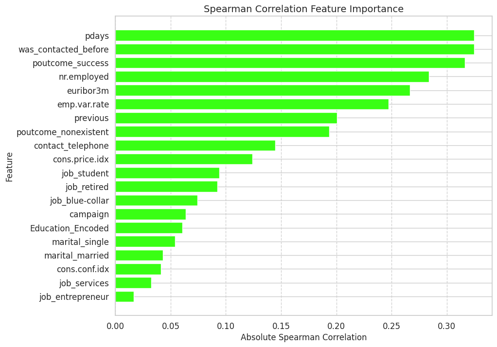

```python
# Compute Spearman correlation scores
spearman_scores = X_fs.apply(lambda col: col.corr(y, method='spearman'))

# Absolute values for ranking
spearman_rank = spearman_scores.abs().sort_values(ascending=False)

# Top features (you can adjust top N)
top_n = 20
spearman_top = spearman_rank.head(top_n)

print("Top Spearman Correlation Features:")
display(spearman_top)

# ============================================
# BAR CHART (Spearman Feature Importance)
# ============================================

plt.figure(figsize=(10, 8))
plt.barh(
    spearman_top.index[::-1],      # reverse for descending order
    spearman_top.values[::-1],
    color="#39FF14"                # verde fluorescente
)

plt.title("Spearman Correlation Feature Importance", fontsize=14)
plt.xlabel("Absolute Spearman Correlation", fontsize=12)
plt.ylabel("Feature", fontsize=12)
plt.grid(axis='x', linestyle='--', alpha=0.3, color='dimgray')  # cinzento escuro

plt.show()
```

**Análise — Spearman Correlation Feature Ranking**

O método de correlação de Spearman mede a força e direção da relação monotónica entre cada variável independente e a variável alvo (y).

Esta métrica é apropriada para este dataset, pois muitas relações não são estritamente lineares, mas podem ser monotónicas.

**Conclusão da Análise Spearman**

As variáveis mais importantes são fortemente relacionadas com:

- Histórico de contacto (pdays, was_contacted_before, previous, poutcome_success);
- Condições económicas globais (nr.employed, euribor3m, emp.var.rate).

As variáveis demográficas e de ocupação apresentam correlações fracas, indicando que não influenciam monotonicamente o target, mas podem ainda agregar valor em modelos complexos.

## Chi-Square

```
Top Chi-Square Features:
```

|  | 0 |
| --- | --- |
| was_contacted_before | 4187.281579 |
| poutcome_success | 3982.548056 |
| previous | 1220.283363 |
| euribor3m | 918.627479 |
| contact_telephone | 547.958309 |
| emp.var.rate | 541.304067 |
| nr.employed | 502.655177 |
| job_student | 355.864620 |
| job_retired | 335.662863 |
| poutcome_nonexistent | 210.627558 |
| job_blue-collar | 176.876859 |
| pdays | 158.928220 |
| marital_single | 86.799505 |
| cons.price.idx | 86.043985 |
| campaign | 55.089970 |
| job_services | 38.832296 |
| marital_married | 29.868864 |
| cons.conf.idx | 13.887591 |
| Education_Encoded | 13.358479 |
| job_entrepreneur | 11.006511 |

**dtype:** float64

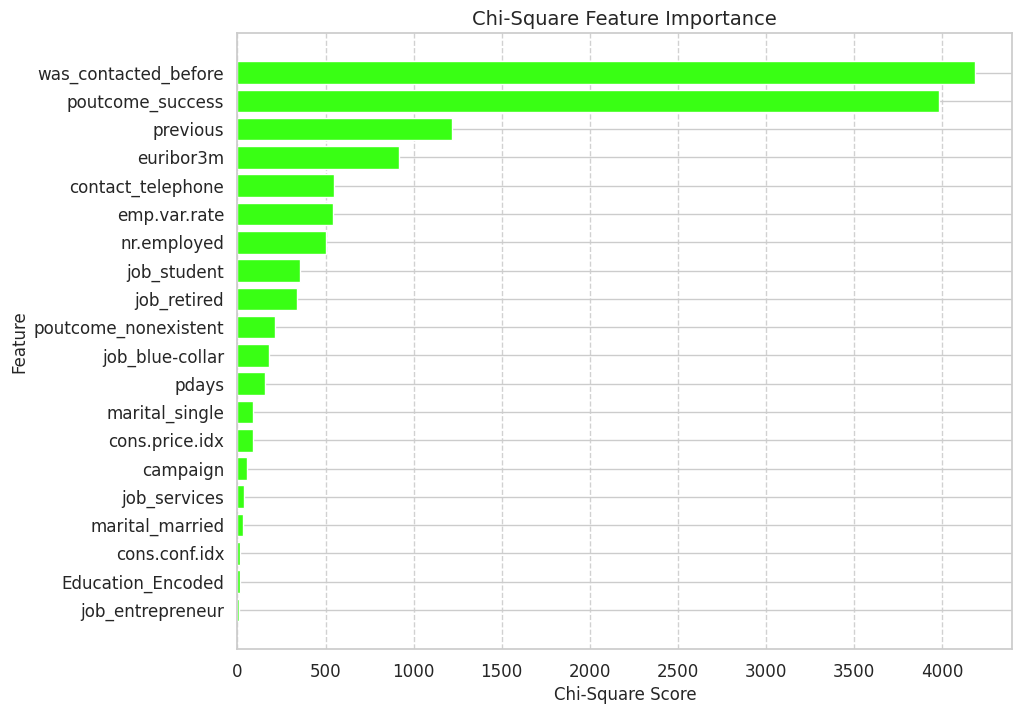

```python
# Scale X to non-negative values (required by Chi-Square)
scaler = MinMaxScaler()
X_chi = scaler.fit_transform(X_fs)

# Compute Chi-Square scores
chi_scores, p_values = chi2(X_chi, y)

chi2_rank = pd.Series(chi_scores, index=X_fs.columns).sort_values(ascending=False)

# Select top N features (adjust if needed)
top_n = 20
chi2_top = chi2_rank.head(top_n)

print("Top Chi-Square Features:")
display(chi2_top)


# ============================================
# BAR CHART (Chi-Square Feature Importance)
# ============================================

plt.figure(figsize=(10, 8))

plt.barh(
    chi2_top.index[::-1],     # reverse so highest is on top
    chi2_top.values[::-1],
    color="#39FF14"           # verde fluorescente
)

plt.title("Chi-Square Feature Importance", fontsize=14)
plt.xlabel("Chi-Square Score", fontsize=12)
plt.ylabel("Feature", fontsize=12)

plt.grid(axis='x', linestyle='--', alpha=0.3, color='dimgray')  # secondary color

plt.show()
```

**Análise — Chi-Square Feature Importance**

O teste Chi-Square (χ²) mede a dependência estatística entre cada feature (não negativa e categorizada/one-hot) e o target (y).

Quanto maior o valor de χ², maior evidência de que a variável e o target NÃO são independentes, ou seja, maior relevância para o modelo.

**Conclusão da Análise Chi-Square**

O método confirma padrões revelados pelo Spearman:

- Histórico de contacto é claramente o maior preditor do sucesso.
- Resultados de campanhas anteriores também são extremamente relevantes.
- Variáveis macroeconómicas (euribor3m, emp.var.rate, nr.employed) têm impacto forte.

Diferenças importantes:

- pdays perde muita força (Spearman forte, Chi-Square fraco → relação monotónica, mas não categórica).
- Variáveis demográficas (job, marital) têm impacto visível mas não decisivo.

O Chi-Square complementa bem o Spearman porque:

- Foca-se em dependência estatística, não em monotonicidade.
- Dá insights adicionais sobre categorias e efeitos discretos.

## Logistic Regression

```python
# Logistic Regression model (scaled input helps convergence)
logreg = LogisticRegression(
    max_iter=10000,
    class_weight='balanced',
    solver='lbfgs'
)

# Build the RFE pipeline
rfe_pipe = Pipeline([
    ('scaler', StandardScaler()),
    ('rfe', RFE(estimator=logreg, n_features_to_select=10))
])

# Fit pipeline
rfe_pipe.fit(X_fs, y)

# Extract selected features
rfe_support = rfe_pipe.named_steps['rfe'].support_
rfe_selected = X_fs.columns[rfe_support].tolist()

print("RFE Selected Features:", rfe_selected)

rfe_table = pd.DataFrame({
    "Selected Features (RFE)": rfe_selected
})

display(rfe_table.style.hide(axis="index"))
```

```
RFE Selected Features: ['pdays', 'emp.var.rate', 'cons.price.idx', 'cons.conf.idx', 'euribor3m', 'nr.employed', 'contact_telephone', 'poutcome_nonexistent', 'poutcome_success', 'was_contacted_before']
```

| Selected Features (RFE) |
| --- |
| pdays |
| emp.var.rate |
| cons.price.idx |
| cons.conf.idx |
| euribor3m |
| nr.employed |
| contact_telephone |
| poutcome_nonexistent |
| poutcome_success |
| was_contacted_before |

**Análise — RFE (Recursive Feature Elimination)**

Ao contrário de Spearman e Chi-Square, que analisam variáveis individualmente, o RFE avalia:

- impacto conjunto das features
- interações entre variáveis
- contribuição marginal no modelo final

Por isso, é particularmente relevante para modelos lineares como a regressão logística.

**Forte presença de indicadores macroeconómicos**

O RFE selecionou **indicadores macroeconómicos**: emp.var.rate, cons.price.idx, cons.conf.idx, euribor3m, nr.employed.

Isto mostra que a regressão logística considera que as condições económicas têm um impacto estruturado, linear e consistente na probabilidade de subscrição.

O RFE também selecionou variaveis relacionadas com ** campanhas, histórico de contacto e meio de contacto**: pdays, was_contacted_before, poutcome_success, poutcome_nonexistent.

**Todos os métodos até agora convergem para as mesmas áreas: macroeconomia + histórico de contacto.**

## LASSO

```
LASSO Selected Features: ['campaign', 'pdays', 'emp.var.rate', 'cons.price.idx', 'cons.conf.idx', 'nr.employed', 'job_blue-collar', 'job_entrepreneur', 'job_management', 'job_retired', 'job_services', 'job_student', 'marital_single', 'contact_telephone', 'poutcome_nonexistent', 'poutcome_success', '…
```

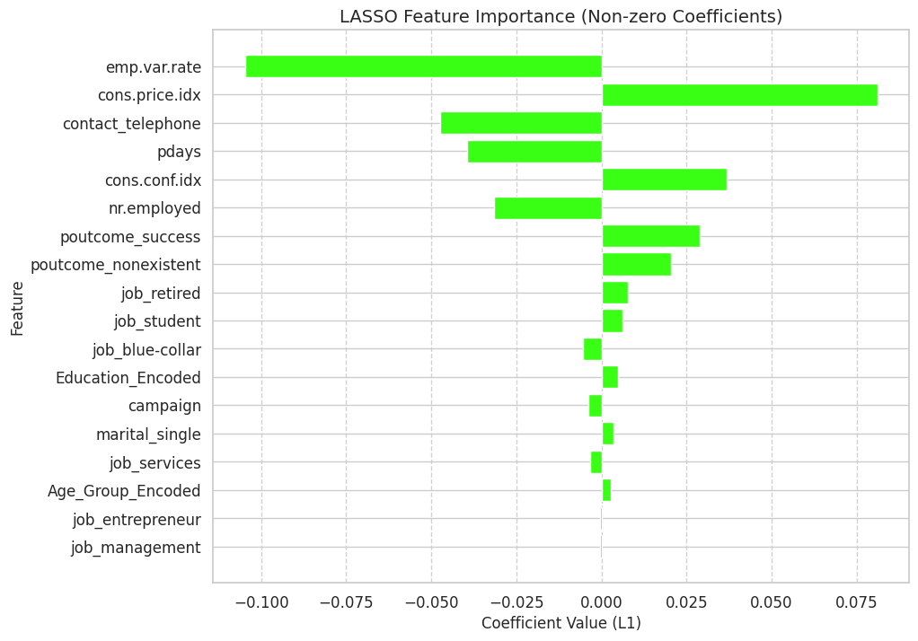

```python
# LASSO pipeline (recommended)
lasso_pipe = Pipeline([
    ('scaler', StandardScaler()),
    ('lasso', Lasso(alpha=0.001, max_iter=10000))
])

lasso_pipe.fit(X_fs, y)

# Extract model coefficients
lasso_coef = lasso_pipe.named_steps['lasso'].coef_

# Select features with non-zero coefficients
lasso_selected = X_fs.columns[lasso_coef != 0].tolist()

print("LASSO Selected Features:", lasso_selected)

# Create a series with non-zero coefficients only
lasso_importance = pd.Series(
    lasso_coef[lasso_coef != 0],
    index=X_fs.columns[lasso_coef != 0]
).sort_values(key=abs, ascending=False)

plt.figure(figsize=(10, 8))

plt.barh(
    lasso_importance.index[::-1],
    lasso_importance.values[::-1],
    color="#39FF14"   # verde fluorescente
)

plt.title("LASSO Feature Importance (Non-zero Coefficients)", fontsize=14)
plt.xlabel("Coefficient Value (L1)", fontsize=12)
plt.ylabel("Feature", fontsize=12)

plt.grid(axis='x', linestyle='--', alpha=0.3, color='dimgray')  # cinzento escuro

plt.show()
```

**Análise — LASSO (L1 Regularization) Feature Importance**

As barras positivas indicam que o aumento da feature leva a um aumento na probabilidade de subscrição.

Takes **positivos** interessantes:

- **poutcome_success** --> Clientes que tiveram uma campanha anterior bem-sucedida têm uma probabilidade significativamente maior de subscrever novamente.
- **poutcome_nonexistent** --> Mesmo nunca tendo participado em campanhas anteriores, essa informação ajuda o modelo a distinguir perfis de clientes.

As barras negativas indicam que um aumento da feature diminui a probabilidade de subscrição.

O LASSO selecionou um conjunto de features que **concorda fortemente com outros métodos** pdays, contact_telephone, macro variáveis, histórico de campanhas são novamente os pilares.

## DECISION TREE

```
Decision Tree Selected Features: ['nr.employed', 'pdays', 'euribor3m', 'cons.conf.idx', 'contact_telephone', 'previous', 'age', 'cons.price.idx', 'campaign', 'job_technician', 'emp.var.rate', 'poutcome_success', 'job_retired', 'job_blue-collar']
```

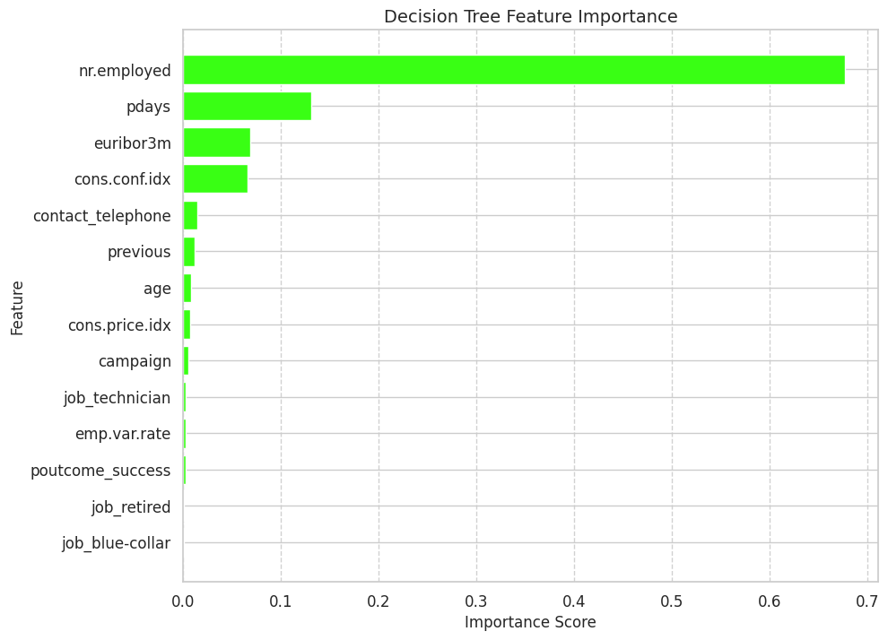

```python
dt = DecisionTreeClassifier(max_depth=5, random_state=42)
dt.fit(X_fs, y)

dt_importances = pd.Series(dt.feature_importances_, index=X_fs.columns)
dt_rank = dt_importances.sort_values(ascending=False)

# Selected features = all features with non-zero importance
dt_selected = dt_rank[dt_rank > 0].index.tolist()

print("Decision Tree Selected Features:", dt_selected)

# Keep only non-zero importance features
dt_nonzero = dt_rank[dt_rank > 0]

plt.figure(figsize=(10, 8))

plt.barh(
    dt_nonzero.index[::-1],        # highest importance on top
    dt_nonzero.values[::-1],
    color="#39FF14"                # verde fluorescente
)

plt.title("Decision Tree Feature Importance", fontsize=14)
plt.xlabel("Importance Score", fontsize=12)
plt.ylabel("Feature", fontsize=12)

plt.grid(axis='x', linestyle='--', alpha=0.3, color='dimgray')

plt.show()
```

**Análise — Decision Tree Feature Importance**

Diferentemente dos métodos lineares (LASSO, RFE), a árvore consegue capturar relações não lineares e interações entre variáveis.

O modelo vê **nr.employed** como o **principal fator preditivo**, sugerindo que o comportamento do consumidor bancário no dataset é altamente sensível ao contexto económico.

A feature **pdays** continua a ser extremamente importante, **alinhado com LASSO, Spearman e RFE**.

**Variáveis macroeconómicas **(euribor3m, cons.conf.idx) surgem como preditores **relevantes**, reforçando o papel do ambiente económico.

**Variáveis como poutcome_success, que tiveram forte impacto noutros métodos, têm quase zero importância aqui.**

A Decision Tree fornece uma perspetiva complementar:

- forte nas relações não lineares;
- sensível à hierarquia dos splits;
- seleciona poucas features-chave com muito peso.

## Features Dropped

```python
all_features = X_fs.columns

summary = pd.DataFrame({
    "Feature": all_features,

    "Spearman": ["X" if feat in spearman_top.index else "" for feat in all_features],
    "Chi-Square": ["X" if feat in chi2_top.index else "" for feat in all_features],
    "RFE": ["YES" if feat in rfe_selected else "" for feat in all_features],
    "LASSO": ["YES" if feat in lasso_selected else "" for feat in all_features],
    "Decision Tree": ["YES" if feat in dt_selected else "" for feat in all_features]
})


# ============================================
# DECISION RULE
# SAME LOGIC AS THE TABLE YOU SHOWED
# ============================================

def decide(row):
    votes = sum([
        row["Spearman"] == "X",
        row["Chi-Square"] == "X",
        row["RFE"] == "YES",
        row["LASSO"] == "YES",
        row["Decision Tree"] == "YES"
    ])

    if votes >= 3:
        return "KEEP"
    elif votes == 2:
        return "TRY WITH/WITHOUT"
    else:
        return "REMOVE"

summary["Decision"] = summary.apply(decide, axis=1)


# ============================================
# DISPLAY FINAL TABLE (NO INDEX)
# ============================================

display(summary.style.hide(axis="index"))
```

| Feature | Spearman | Chi-Square | RFE | LASSO | Decision Tree | Decision |
| --- | --- | --- | --- | --- | --- | --- |
| age |  |  |  |  | YES | REMOVE |
| housing |  |  |  |  |  | REMOVE |
| loan |  |  |  |  |  | REMOVE |
| campaign | X | X |  | YES | YES | KEEP |
| pdays | X | X | YES | YES | YES | KEEP |
| previous | X | X |  |  | YES | KEEP |
| emp.var.rate | X | X | YES | YES | YES | KEEP |
| cons.price.idx | X | X | YES | YES | YES | KEEP |
| cons.conf.idx | X | X | YES | YES | YES | KEEP |
| euribor3m | X | X | YES |  | YES | KEEP |
| nr.employed | X | X | YES | YES | YES | KEEP |
| job_blue-collar | X | X |  | YES | YES | KEEP |
| job_entrepreneur | X | X |  | YES |  | KEEP |
| job_housemaid |  |  |  |  |  | REMOVE |
| job_management |  |  |  | YES |  | REMOVE |
| job_retired | X | X |  | YES | YES | KEEP |
| job_self-employed |  |  |  |  |  | REMOVE |
| job_services | X | X |  | YES |  | KEEP |
| job_student | X | X |  | YES |  | KEEP |
| job_technician |  |  |  |  | YES | REMOVE |
| job_unemployed |  |  |  |  |  | REMOVE |
| marital_married | X | X |  |  |  | TRY WITH/WITHOUT |
| marital_single | X | X |  | YES |  | KEEP |
| contact_telephone | X | X | YES | YES | YES | KEEP |
| poutcome_nonexistent | X | X | YES | YES |  | KEEP |
| poutcome_success | X | X | YES | YES | YES | KEEP |
| was_contacted_before | X | X | YES |  |  | KEEP |
| Age_Group_Encoded |  |  |  | YES |  | REMOVE |
| Education_Encoded | X | X |  | YES |  | KEEP |

```python
cols_to_drop_fs = [
    'age',
    'housing',
    'loan',
    'job_housemaid',
    'job_management',
    'job_self-employed',
    'job_technician',
    'job_unemployed',
    'Age_Group_Encoded'
]

X = df_pp.drop(cols_to_drop + cols_to_drop_fs + ['y'], axis=1)

X
```

|  | campaign | pdays | previous | emp.var.rate | cons.price.idx | cons.conf.idx | euribor3m | nr.employed | job_blue-collar | job_entrepreneur | job_retired | job_services | job_student | marital_married | marital_single | contact_telephone | poutcome_nonexistent | poutcome_success | was_contacted_before | Education_Encoded |
| --- | --- | --- | --- | --- | --- | --- | --- | --- | --- | --- | --- | --- | --- | --- | --- | --- | --- | --- | --- | --- |
| 0 | 1 | 999 | 0 | 1.1 | 93.994 | -36.4 | 4.857 | 5191.0 | False | False | False | False | False | True | False | True | True | False | 0 | 1 |
| 1 | 1 | 999 | 0 | 1.1 | 93.994 | -36.4 | 4.857 | 5191.0 | False | False | False | True | False | True | False | True | True | False | 0 | 4 |
| 2 | 1 | 999 | 0 | 1.1 | 93.994 | -36.4 | 4.857 | 5191.0 | False | False | False | True | False | True | False | True | True | False | 0 | 4 |
| 3 | 1 | 999 | 0 | 1.1 | 93.994 | -36.4 | 4.857 | 5191.0 | False | False | False | False | False | True | False | True | True | False | 0 | 2 |
| 4 | 1 | 999 | 0 | 1.1 | 93.994 | -36.4 | 4.857 | 5191.0 | False | False | False | True | False | True | False | True | True | False | 0 | 4 |
| ... | ... | ... | ... | ... | ... | ... | ... | ... | ... | ... | ... | ... | ... | ... | ... | ... | ... | ... | ... | ... |
| 41183 | 1 | 999 | 0 | -1.1 | 94.465 | -49.5 | 1.028 | 4963.6 | False | False | True | False | False | True | False | False | True | False | 0 | 5 |
| 41184 | 1 | 999 | 0 | -1.1 | 94.465 | -49.5 | 1.028 | 4963.6 | True | False | False | False | False | True | False | False | True | False | 0 | 5 |
| 41185 | 2 | 999 | 0 | -1.1 | 94.465 | -49.5 | 1.028 | 4963.6 | False | False | True | False | False | True | False | False | True | False | 0 | 6 |
| 41186 | 1 | 999 | 0 | -1.1 | 94.465 | -49.5 | 1.028 | 4963.6 | False | False | False | False | False | True | False | False | True | False | 0 | 5 |
| 41187 | 3 | 999 | 1 | -1.1 | 94.465 | -49.5 | 1.028 | 4963.6 | False | False | True | False | False | True | False | False | False | False | 0 | 5 |

41188 rows × 20 columns

Removemos duration pois verificamos que podia dar leak, pois o duration é obtivo após a chamada ser finalizada e sabermos a resposta do cliente. Para além disso foi também verificado uma relação com respostas positivas no EDA com chamadas com durações maiores, o que faz todo o sentido.

Train-test split

```python
from sklearn.model_selection import train_test_split

X_train, X_test, y_train, y_test = train_test_split(
    X, y, test_size=0.2, random_state=42, stratify=y
)
```

# Modeling

## Logistic Regression

### Default 0.5 Threshold

```python
# Build pipeline with scaling
logreg_model = Pipeline([
    ('scaler', StandardScaler()),
    ('logreg', LogisticRegression(
        max_iter=5000,
        class_weight='balanced'
    ))
])

# Train model
logreg_model.fit(X_train, y_train)

# Predictions
y_pred = logreg_model.predict(X_test)
y_proba = logreg_model.predict_proba(X_test)[:, 1]

# Evaluation
print("Logistic Regression ROC-AUC:", roc_auc_score(y_test, y_proba))
print("\nClassification Report:\n", classification_report(y_test, y_pred))
print("Confusion Matrix:\n", confusion_matrix(y_test, y_pred))
```

```
Logistic Regression ROC-AUC: 0.7920028657012124

Classification Report:
               precision    recall  f1-score   support

           0       0.95      0.80      0.87      7310
           1       0.30      0.69      0.42       928

    accuracy                           0.79      8238
   macro avg       0.63      0.74      0.65      8238
weighted avg       0.88      0.79      0.82      8238

Confusion Matrix:
 [[5853 1457]
 [ 289  639]]
```

#### Analise dos resultados iniciais

**Interpretação da Confusion Matrix**

**Interpretação das métricas** Classe 0 (NO)

Precision = 0.95 → quase todos os que o modelo marca como NO são realmente NO Recall = 0.80 → 20% dos NO são mal classificados como YES

Classe 1 (YES) → a mais importante para o banco

Precision = 0.30 → quando o modelo diz YES, só 30% são realmente YES → muitos falsos positivos Recall = 0.69 → identifica 69% dos clientes que diriam YES → bom para marketing, porque reduz clientes perdidos F1 = 0.42 → baixo, devido à precision reduzida

**Accuracy** = 0.79 → não é a melhor métrica aqui, dado o desbalanceamento do dataset.

**ROC-AUC** = 0.792 → modelo razoável a separar YES de NO, mas longe do ideal.

O dataset está desiquilibrado: a grande maioria dos clientes não subscreve, o que dificulta a previsão da classe YES.

```python
y.value_counts(normalize=True)
```

| y | proportion |
| --- | --- |
| 0 | 0.887346 |
| 1 | 0.112654 |

**dtype:** float64

### Fine tuning the Threshold

```
Best threshold by F1 score: 0.62, F1: 0.50
```

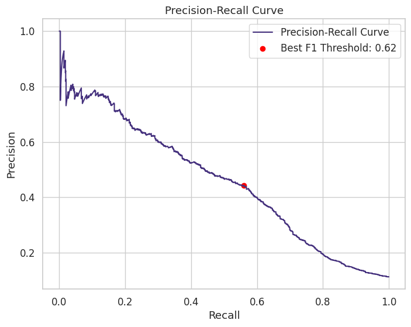

```
ROC-AUC: 0.7920028657012124

Classification Report (threshold adjusted):
               precision    recall  f1-score   support

           0       0.94      0.91      0.93      7310
           1       0.44      0.56      0.50       928

    accuracy                           0.87      8238
   macro avg       0.69      0.74      0.71      8238
weighted avg       0.89      0.87      0.88      8238

Confusion Matrix:
 [[6657  653]
 [ 408  520]]
```

```python
import numpy as np
import matplotlib.pyplot as plt
from sklearn.metrics import precision_recall_curve, f1_score

y_proba = logreg_model.predict_proba(X_test)[:, 1]

precision, recall, thresholds = precision_recall_curve(y_test, y_proba)

# F1 scores para todos os thresholds
f1_scores = 2 * (precision * recall) / (precision + recall + 1e-10)  # avoid division by zero

# Melhor F1 score
best_idx = np.argmax(f1_scores)
best_threshold = thresholds[best_idx]
print(f"Best threshold by F1 score: {best_threshold:.2f}, F1: {f1_scores[best_idx]:.2f}")

# Plot curva precision-recall
plt.figure(figsize=(8,6))
plt.plot(recall, precision, label='Precision-Recall Curve')
plt.scatter(recall[best_idx], precision[best_idx], color='red', label=f'Best F1 Threshold: {best_threshold:.2f}')
plt.xlabel('Recall')
plt.ylabel('Precision')
plt.title('Precision-Recall Curve')
plt.legend()
plt.show()

# Usar novo threshold
y_pred_threshold = (y_proba >= best_threshold).astype(int)

# Avaliação
from sklearn.metrics import classification_report, confusion_matrix, roc_auc_score

print("ROC-AUC:", roc_auc_score(y_test, y_proba))
print("\nClassification Report (threshold adjusted):\n", classification_report(y_test, y_pred_threshold))
print("Confusion Matrix:\n", confusion_matrix(y_test, y_pred_threshold))
```

Após ajustarmos o threshold de decisão do modelo de regressão logística, observou-se uma alteração clara no comportamento do modelo.

A precisão da classe minoritária (YES) é agora 44%, mostrando que ainda existe um número significativo de falsos positivos, embora haja alguma melhoria na estabilidade do modelo.

O recall da classe minoritária é 56%, indicando que o modelo consegue identificar mais de metade dos clientes que iriam subscrever, mas com um desempenho inferior ao obtido antes do ajuste.

A F1 da classe minoritária é 0.50, refletindo um equilíbrio razoável entre precisão e recall, mas ainda limitado pelo número elevado de previsões incorretas na classe YES.

A accuracy global é 0.87, consistente com o comportamento geral do modelo, embora esta métrica continue a não ser ideal devido ao desbalanceamento do dataset.

O ROC-AUC mantém-se em 0.79, mostrando que a capacidade do modelo para distinguir entre clientes que subscrevem e não subscrevem permanece moderada.

## Random Forest

### Default 0.5 Threshold

```python
from sklearn.ensemble import RandomForestClassifier
from sklearn.metrics import classification_report, confusion_matrix, roc_auc_score
from sklearn.pipeline import Pipeline
from sklearn.preprocessing import StandardScaler

# Criar pipeline
rf_model = Pipeline([
    ('scaler', StandardScaler()),  # opcional, RF não precisa de escala, mas mantemos para consistência
    ('rf', RandomForestClassifier(
        n_estimators=500,
        class_weight='balanced',
        random_state=42
    ))
])

# Treinar modelo
rf_model.fit(X_train, y_train)

# Previsões
y_pred_rf = rf_model.predict(X_test)
y_proba_rf = rf_model.predict_proba(X_test)[:, 1]

# Avaliação
print("Random Forest ROC-AUC:", roc_auc_score(y_test, y_proba_rf))
print("\nClassification Report:\n", classification_report(y_test, y_pred_rf))
print("Confusion Matrix:\n", confusion_matrix(y_test, y_pred_rf))
```

```
Random Forest ROC-AUC: 0.7286658568800416

Classification Report:
               precision    recall  f1-score   support

           0       0.92      0.90      0.91      7310
           1       0.35      0.41      0.38       928

    accuracy                           0.85      8238
   macro avg       0.64      0.66      0.64      8238
weighted avg       0.86      0.85      0.85      8238

Confusion Matrix:
 [[6602  708]
 [ 550  378]]
```

O Random Forest obteve um ROC-AUC de 0.728, mas ainda não é o melhor modelo para detetar a classe minoritária no estado atual.

Se o objetivo é captar a maioria dos casos positivos, a regressão logística com threshold ajustado continua a ter melhor desempenho.

Como fizemos antes, será necessário ajustar o threshold para a classe 1 no Random Forest para tentar melhorar o recall (0.41) e o F1 (0.38).

No modelo atual, o Random Forest apresenta 92% de precisão para a classe 0, mas apenas 35% de precisão para a classe 1, indicando muitos falsos positivos. O recall da classe minoritária é 0.41, captando menos da metade dos casos positivos. A accuracy global é 0.85, alinhada com o desequilíbrio do dataset.

A confusion matrix mostra: — 6602 TN — 708 FP — 550 FN — 378 TP

Estes valores reforçam que o modelo, apesar de estável e com bom desempenho na classe majoritária, ainda necessita de otimização direcionada para melhorar a deteção da classe de interesse.

```python
# parametros alterados p evitar overfitting

from sklearn.ensemble import RandomForestClassifier
from sklearn.pipeline import Pipeline

rf_model = Pipeline([
    ('rf', RandomForestClassifier(
        n_estimators=300,
        max_depth=10,
        min_samples_split=20,
        min_samples_leaf=10,
        max_features='sqrt',
        class_weight='balanced',
        random_state=42,
        n_jobs=-1
    ))
])

rf_model.fit(X_train, y_train)

# Avaliação
y_pred_rf = rf_model.predict(X_test)
y_proba_rf = rf_model.predict_proba(X_test)[:, 1]

print("Random Forest ROC-AUC:", roc_auc_score(y_test, y_proba_rf))
print("\nClassification Report:\n", classification_report(y_test, y_pred_rf))
print("Confusion Matrix:\n", confusion_matrix(y_test, y_pred_rf))
```

```
Random Forest ROC-AUC: 0.8126128443558658

Classification Report:
               precision    recall  f1-score   support

           0       0.95      0.88      0.91      7310
           1       0.41      0.65      0.50       928

    accuracy                           0.85      8238
   macro avg       0.68      0.76      0.71      8238
weighted avg       0.89      0.85      0.87      8238

Confusion Matrix:
 [[6439  871]
 [ 328  600]]
```

| Métrica | **Resultado 1 (Conservador)** | **Resultado 2 (Agressivo)** |
| --- | --- | --- |
| ROC-AUC | **0.813** | 0.813 |
| Accuracy | **0.85** | 0.85 |
| Classe 1 – Precision | **0.41** | 0.41 |
| Classe 1 – Recall | 0.65 | **0.65** |
| Classe 1 – F1 | 0.50 | **0.50** |
| Classe 0 – Precision | 0.95 | **0.95** |
| Classe 0 – Recall | **0.88** | 0.88 |
| Macro F1 | 0.71 | 0.71 |
| Weighted F1 | **0.87** | 0.87 |

| Métrica | **Resultado 1** | **Resultado 2** |
| --- | --- | --- |
| True Negatives (TN) | **6439** | 6439 |
| False Positives (FP) | **871** | 871 |
| False Negatives (FN) | 328 | **328** |
| True Positives (TP) | 600 | **600** |

### Fine tuning the Threshold

Resultado 1

```
Melhor threshold pelo F1: 0.69, F1: 0.53
```

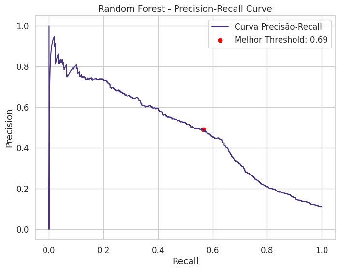

```
ROC-AUC: 0.8126128443558658

Classification Report (threshold adjusted):
               precision    recall  f1-score   support

           0       0.94      0.93      0.93      7310
           1       0.49      0.56      0.53       928

    accuracy                           0.88      8238
   macro avg       0.72      0.75      0.73      8238
weighted avg       0.89      0.88      0.89      8238

Confusion Matrix:
 [[6766  544]
 [ 404  524]]
```

```python
import numpy as np
import matplotlib.pyplot as plt
from sklearn.metrics import precision_recall_curve, f1_score, classification_report, confusion_matrix, roc_auc_score

# Probabilidades preditas
y_proba_rf = rf_model.predict_proba(X_test)[:, 1]

# Curva precisão-recall
precision, recall, thresholds = precision_recall_curve(y_test, y_proba_rf)

# Calcular F1 para cada threshold
f1_scores = 2 * (precision * recall) / (precision + recall + 1e-10)  # evita divisão por zero

# Encontrar o threshold que maximiza o F1
best_idx = np.argmax(f1_scores)
best_threshold_rf = thresholds[best_idx]
print(f"Melhor threshold pelo F1: {best_threshold_rf:.2f}, F1: {f1_scores[best_idx]:.2f}")

# Plot da curva precisão-recall
plt.figure(figsize=(8,6))
plt.plot(recall, precision, label='Curva Precisão-Recall')
plt.scatter(recall[best_idx], precision[best_idx], color='red', label=f'Melhor Threshold: {best_threshold_rf:.2f}')
plt.xlabel('Recall')
plt.ylabel('Precision')
plt.title('Random Forest - Precision-Recall Curve')
plt.legend()
plt.show()

# Aplicar novo threshold
y_pred_rf_threshold = (y_proba_rf >= best_threshold_rf).astype(int)

# Avaliação com threshold ajustado
print("ROC-AUC:", roc_auc_score(y_test, y_proba_rf))
print("\nClassification Report (threshold adjusted):\n", classification_report(y_test, y_pred_rf_threshold))
print("Confusion Matrix:\n", confusion_matrix(y_test, y_pred_rf_threshold))
```

Após ajustarmos o threshold do Random Forest para 0,69 (em vez do valor padrão 0,5), observou-se uma melhoria no desempenho da classe minoritária:

O F1 da classe 1 aumentou para 0.53, mostrando um equilíbrio mais sólido entre precisão e recall.

A classe 0 (maioritária) mantém um desempenho forte, com 94% de precisão e 93% de recall.

A accuracy global situa-se em 88%, e o ROC-AUC mantém-se consistente (0.813), refletindo uma capacidade estável do modelo em separar as duas classes.

Resultado 2

```python
import numpy as np
from sklearn.metrics import f1_score

# Probabilidades previstas
y_proba = rf_model.predict_proba(X_test)[:, 1]

thresholds = np.arange(0.1, 0.9, 0.01)
f1_scores = []

for t in thresholds:
    y_pred_t = (y_proba >= t).astype(int)
    f1 = f1_score(y_test, y_pred_t, pos_label=1)
    f1_scores.append(f1)

best_threshold = thresholds[np.argmax(f1_scores)]
best_f1 = max(f1_scores)

print(f"Melhor threshold: {best_threshold:.2f}")
print(f"Melhor F1 (classe 1): {best_f1:.3f}")
```

```
Melhor threshold: 0.69
Melhor F1 (classe 1): 0.524
```

```python
from sklearn.metrics import classification_report, confusion_matrix

y_pred_opt = (y_proba >= best_threshold).astype(int)

print(classification_report(y_test, y_pred_opt))
print(confusion_matrix(y_test, y_pred_opt))
```

```
              precision    recall  f1-score   support

           0       0.94      0.92      0.93      7310
           1       0.49      0.56      0.52       928

    accuracy                           0.88      8238
   macro avg       0.72      0.74      0.73      8238
weighted avg       0.89      0.88      0.89      8238

[[6761  549]
 [ 404  524]]
```

### Comparação

| **Metric / Class** | **Logistic Regression** | **RF – Resultado 1** | **RF – Resultado 2** |
| --- | --- | --- | --- |
| **ROC-AUC** | 0.792 | **0.813** | **0.813** |
| **Accuracy** | 0.87 | **0.88** | **0.88** |
| **Class 0 Precision** | 0.94 | **0.94** | **0.94** |
| **Class 0 Recall** | 0.91 | **0.93** | 0.92 |
| **Class 0 F1** | 0.93 | **0.93** | **0.93** |
| **Class 1 Precision** | 0.44 | **0.49** | **0.49** |
| **Class 1 Recall** | 0.56 | **0.56** | **0.56** |
| **Class 1 F1** | 0.50 | **0.53** | **0.52** |

Após regularização e otimização do threshold, o modelo Random Forest demonstrou uma melhoria consistente face à regressão logística, especialmente no desempenho da classe minoritária, evidenciando maior capacidade de generalização e flexibilidade na gestão do trade-off entre precision e recall.

## XGBoost

### Default 0.5 Threshold

```python
import xgboost as xgb
from sklearn.metrics import classification_report, confusion_matrix, roc_auc_score
import matplotlib.pyplot as plt

# 1. Codificar colunas categóricas
for col in X_train.select_dtypes(include=['category']).columns:
    X_train[col] = X_train[col].cat.codes
    X_test[col] = X_test[col].cat.codes

# 2. Calcular scale_pos_weight
scale_pos_weight = sum(y_train == 0) / sum(y_train == 1)
print(f"scale_pos_weight: {scale_pos_weight:.2f}")

# 3. Criar e treinar modelo XGBoost
xgb_model = xgb.XGBClassifier(
    n_estimators=500,
    max_depth=5,
    learning_rate=0.1,
    scale_pos_weight=scale_pos_weight,
    eval_metric='logloss',
    random_state=42
)

xgb_model.fit(X_train, y_train)

# 4. Previsões com threshold default (0.5)
y_pred_xgb = xgb_model.predict(X_test)
y_proba_xgb = xgb_model.predict_proba(X_test)[:, 1]


# 5. Avaliação
print("\nROC-AUC:", round(roc_auc_score(y_test, y_proba_xgb), 3))
print("\nClassification Report (threshold=0.5):")
print(classification_report(y_test, y_pred_xgb))
print("Confusion Matrix:\n", confusion_matrix(y_test, y_pred_xgb))
```

```
scale_pos_weight: 7.88

ROC-AUC: 0.799

Classification Report (threshold=0.5):
              precision    recall  f1-score   support

           0       0.95      0.87      0.91      7310
           1       0.38      0.63      0.47       928

    accuracy                           0.84      8238
   macro avg       0.66      0.75      0.69      8238
weighted avg       0.89      0.84      0.86      8238

Confusion Matrix:
 [[6346  964]
 [ 339  589]]
```

Com o XGBoost usando scale_pos_weight = 7.88 e threshold padrão de 0,5, o modelo apresenta um desempenho sólido, com ROC-AUC de 0.799 e accuracy de 84%.

A classe maioritária (0) mantém excelente precisão (0.95) e bom recall (0.87), mostrando que o modelo identifica corretamente a maioria dos clientes que não subscrevem.

A classe minoritária (1) apresenta desempenho moderado, com precisão de 0.38 e recall de 0.63, refletindo a melhoria obtida pelo uso do scale_pos_weight, embora ainda haja falsos positivos e falsos negativos relevantes.

A matriz de confusão mostra 339 falsos negativos e 964 falsos positivos, indicando que o modelo ainda perde uma parte significativa dos casos positivos e que poderá beneficiar de ajuste de threshold para melhorar o equilíbrio entre precisão e recall.

### Fine tuning the Threshold

```
Melhor threshold pelo F1: 0.74, F1: 0.51
```

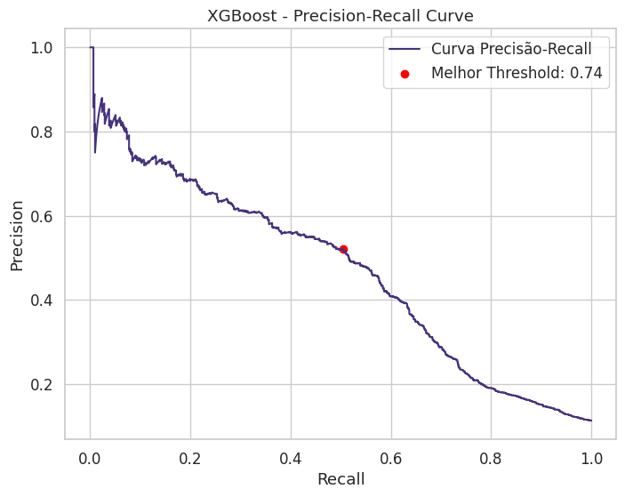

```
ROC-AUC: 0.799

Classification Report (threshold ajustado):
              precision    recall  f1-score   support

           0       0.94      0.94      0.94      7310
           1       0.52      0.50      0.51       928

    accuracy                           0.89      8238
   macro avg       0.73      0.72      0.73      8238
weighted avg       0.89      0.89      0.89      8238

Confusion Matrix:
 [[6880  430]
 [ 460  468]]
```

```python
import numpy as np
import matplotlib.pyplot as plt
from sklearn.metrics import precision_recall_curve, f1_score, classification_report, confusion_matrix, roc_auc_score

# 1. Probabilidades preditas
y_proba_xgb = xgb_model.predict_proba(X_test)[:, 1]

# 2. Curva precisão-recall
precision, recall, thresholds = precision_recall_curve(y_test, y_proba_xgb)

# 3. Calcular F1 para cada threshold
f1_scores = 2 * (precision * recall) / (precision + recall + 1e-10)  # evita divisão por zero

# 4. Encontrar o threshold que maximiza F1
best_idx = np.argmax(f1_scores)
best_threshold_xgb = thresholds[best_idx]
print(f"Melhor threshold pelo F1: {best_threshold_xgb:.2f}, F1: {f1_scores[best_idx]:.2f}")

# 5. Aplicar novo threshold
y_pred_xgb_threshold = (y_proba_xgb >= best_threshold_xgb).astype(int)

# 6. Plot Precision-Recall Curve
plt.figure(figsize=(8,6))
plt.plot(recall, precision, label='Curva Precisão-Recall')
plt.scatter(recall[best_idx], precision[best_idx], color='red', label=f'Melhor Threshold: {best_threshold_xgb:.2f}')
plt.xlabel('Recall')
plt.ylabel('Precision')
plt.title('XGBoost - Precision-Recall Curve')
plt.legend()
plt.show()

# 7. Avaliação com threshold ajustado
print("ROC-AUC:", round(roc_auc_score(y_test, y_proba_xgb), 3))
print("\nClassification Report (threshold ajustado):")
print(classification_report(y_test, y_pred_xgb_threshold))
print("Confusion Matrix:\n", confusion_matrix(y_test, y_pred_xgb_threshold))
```

Após otimizar o threshold para maximizar o F1 da classe minoritária, o XGBoost apresenta um ROC-AUC de 0.799 e mantém uma accuracy global de 89%.

A classe maioritária (0) continua muito bem classificada, com F1 de 0.94 e recall de 0.94, mostrando excelente consistência na identificação de clientes que não subscrevem.

A matriz de confusão mostra 460 falsos negativos e 430 falsos positivos, indicando um compromisso mais estável entre capturar potenciais subscritores e controlar falsos alarmes.

### Comparação

| **Metric / Class** | **Logistic Regression** | **RF – Resultado 1** | **RF – Resultado 2** | **XGBoost** |
| --- | --- | --- | --- | --- |
| **ROC-AUC** | 0.792 | **0.813** | **0.813** | 0.799 |
| **Accuracy** | 0.87 | **0.88** | **0.88** | **0.89** |
| **Class 0 Precision** | 0.94 | **0.94** | **0.94** | **0.94** |
| **Class 0 Recall** | 0.91 | **0.93** | 0.92 | **0.94** |
| **Class 0 F1** | 0.93 | **0.93** | **0.93** | **0.94** |
| **Class 1 Precision** | 0.44 | **0.49** | **0.49** | **0.52** |
| **Class 1 Recall** | 0.56 | **0.56** | **0.56** | 0.50 |
| **Class 1 F1** | 0.50 | **0.53** | **0.52** | 0.51 |

Os resultados mostram que o Random Forest, em ambas as variantes com threshold otimizado, continua a apresentar o melhor desempenho global na classificação da adesão às campanhas bancárias. Destaca-se pelo maior ROC-AUC (0.813) e por um equilíbrio consistente entre precision e recall da classe 1, alcançando F1 entre 0.52 e 0.53 — superior ao da Regressão Logística e ligeiramente acima do XGBoost.

O RF Resultado 1 mantém o melhor desempenho na classe minoritária com F1 = 0.53, enquanto o RF Resultado 2 apresenta valores muito próximos (F1 = 0.52), reforçando a estabilidade do modelo. A Regressão Logística mostra desempenho sólido mas inferior, especialmente na precisão da classe 1 (0.44). Já o XGBoost, apesar de alcançar a maior accuracy global (0.89) e excelente desempenho na classe 0, apresenta recall mais baixo na classe 1 (0.50), tornando-o o menos eficaz na deteção de potenciais aderentes neste cenário.

## SHAP

```python
import shap
import matplotlib.pyplot as plt

#rf_model_tree = rf_model.named_steps['rf']

#explainer = shap.TreeExplainer(rf_model_tree)
#shap_values = explainer.shap_values(X_test)  # X_test já deve estar transformado pelo scaler

# Se o pipeline tem scaler, tens de aplicar antes
#X_test_scaled = rf_model.named_steps['scaler'].transform(X_test)

#shap_values = explainer.shap_values(X_test_scaled)

# Feature importance global
#shap.summary_plot(shap_values[1], X_test, plot_type="bar")

# Summary plot
#shap.summary_plot(shap_values[1], X_test)

# Dependence plot
#feature_mais_importante = X_test.columns[0]  # substitui pela feature top
#shap.dependence_plot(feature_mais_importante, shap_values[1], X_test)
```

## CatBoost

### Model Training

```python
!pip install catboost

from catboost import CatBoostClassifier

cat_model = CatBoostClassifier(
    iterations=500,
    learning_rate=0.05,
    depth=6,
    loss_function='Logloss',
    random_seed=42,
    verbose=100
)

cat_model.fit(X_train, y_train)
```

```
0:	learn: 0.6414907	total: 14.7ms	remaining: 7.32s
100:	learn: 0.2699954	total: 1.76s	remaining: 6.95s
200:	learn: 0.2636627	total: 2.67s	remaining: 3.98s
300:	learn: 0.2584670	total: 3.59s	remaining: 2.38s
400:	learn: 0.2542165	total: 4.51s	remaining: 1.11s
499:	learn: 0.2503675	total: 5.43s	remaining: 0us
```

```
<catboost.core.CatBoostClassifier at 0x7ea3ba362570>
```

### Default 0.5 Threshold

```python
# basic evaluation, no optimized threshold

from sklearn.metrics import (
    roc_auc_score,
    average_precision_score
)

y_proba = cat_model.predict_proba(X_test)[:, 1]

roc_auc = roc_auc_score(y_test, y_proba)
pr_auc = average_precision_score(y_test, y_proba)

print(f"ROC AUC: {roc_auc:.4f}")
print(f"PR AUC: {pr_auc:.4f}")
```

```
ROC AUC: 0.8138
PR AUC: 0.4854
```

### Fine tuning the Threshold

```python
# analyze several thresholds

import numpy as np
from sklearn.metrics import (
    f1_score,
    precision_score,
    recall_score
)

thresholds = np.arange(0.1, 0.91, 0.01)

results = []

for t in thresholds:
    y_pred = (y_proba >= t).astype(int)

    results.append({
        'threshold': t,
        'precision': precision_score(y_test, y_pred),
        'recall': recall_score(y_test, y_pred),
        'f1': f1_score(y_test, y_pred)
    })

results_df = pd.DataFrame(results)
```

```python
# select best threshold

best_row = results_df.loc[results_df['f1'].idxmax()]

best_threshold = best_row['threshold']
best_precision = best_row['precision']
best_recall = best_row['recall']
best_f1 = best_row['f1']

print(f"Best threshold: {best_threshold:.2f}")
print(f"Precision: {best_precision:.3f}")
print(f"Recall: {best_recall:.3f}")
print(f"F1-score: {best_f1:.3f}")
```

```
Best threshold: 0.24
Precision: 0.494
Recall: 0.569
F1-score: 0.529
```

```python
from sklearn.metrics import confusion_matrix, classification_report

y_pred_final = (y_proba >= best_threshold).astype(int)

print("Confusion Matrix:")
print(confusion_matrix(y_test, y_pred_final))

print("\nClassification Report:")
print(classification_report(y_test, y_pred_final))
```

```
Confusion Matrix:
[[6769  541]
 [ 400  528]]

Classification Report:
              precision    recall  f1-score   support

           0       0.94      0.93      0.94      7310
           1       0.49      0.57      0.53       928

    accuracy                           0.89      8238
   macro avg       0.72      0.75      0.73      8238
weighted avg       0.89      0.89      0.89      8238
```

Após ajustar o threshold para maximizar o F1 da classe minoritária, o CatBoost atinge uma accuracy global de 89%, mantendo um desempenho robusto no conjunto de teste.

A classe maioritária (0) apresenta elevada estabilidade, com F1-score de 0.94 e recall de 0.93, reforçando a capacidade do modelo em identificar corretamente clientes que não subscrevem a campanha.

Para a classe minoritária (1), observa-se um desempenho moderado mas equilibrado: o modelo alcança recall de 57% e F1-score de 0.53, evidenciando uma melhoria na deteção de potenciais subscritores, embora com precisão de 0.49, refletindo o compromisso entre captar mais positivos e controlar falsos alarmes.

A matriz de confusão mostra 400 falsos negativos e 541 falsos positivos, ilustrando um trade-off compatível com o contexto de marketing bancário, onde captar mais clientes com probabilidade de aderir tende a ser preferível face ao custo de contactos adicionais.

### Trade-off visualization

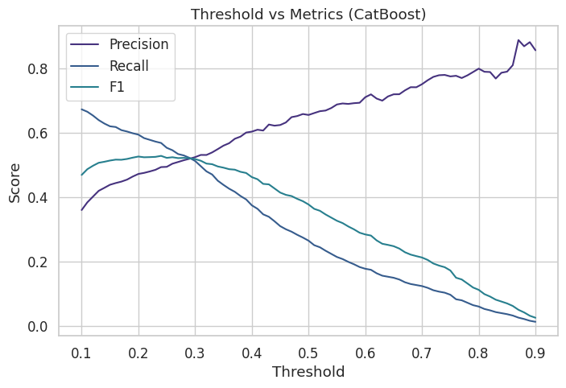

```python
import matplotlib.pyplot as plt

plt.figure(figsize=(8,5))
plt.plot(results_df['threshold'], results_df['precision'], label='Precision')
plt.plot(results_df['threshold'], results_df['recall'], label='Recall')
plt.plot(results_df['threshold'], results_df['f1'], label='F1')
plt.xlabel('Threshold')
plt.ylabel('Score')
plt.legend()
plt.title('Threshold vs Metrics (CatBoost)')
plt.show()
```

### Comparação

[output not shown]

Na classe 1 (clientes que aderem à campanha), o CatBoost apresenta um desempenho equilibrado, com F1 = 0.53, precision = 0.49 e recall = 0.57 — métricas semelhantes às obtidas pelo Random Forest otimizado. Isto demonstra que o modelo consegue identificar uma proporção razoável de subscritores, mantendo um nível de falsos positivos controlado.

Training split metrics for each

```python
from sklearn.metrics import roc_auc_score, accuracy_score, precision_score, recall_score, f1_score

# Função para calcular métricas
def print_metrics(model, X, y, model_name="Model"):
    # Previsões
    y_pred = model.predict(X)

    # Probabilidades para ROC-AUC
    try:
        y_prob = model.predict_proba(X)[:,1]
    except:
        y_prob = model.predict(X)  # caso não tenha predict_proba

    # Métricas gerais
    roc_auc = roc_auc_score(y, y_prob)
    acc = accuracy_score(y, y_pred)

    # Métricas por classe
    precision_0 = precision_score(y, y_pred, pos_label=0)
    recall_0 = recall_score(y, y_pred, pos_label=0)
    f1_0 = f1_score(y, y_pred, pos_label=0)

    precision_1 = precision_score(y, y_pred, pos_label=1)
    recall_1 = recall_score(y, y_pred, pos_label=1)
    f1_1 = f1_score(y, y_pred, pos_label=1)

    print(f"=== {model_name} (Train) ===")
    print(f"ROC-AUC: {roc_auc:.3f}")
    print(f"Accuracy: {acc:.3f}")
    print(f"Class 0 -> Precision: {precision_0:.3f}, Recall: {recall_0:.3f}, F1: {f1_0:.3f}")
    print(f"Class 1 -> Precision: {precision_1:.3f}, Recall: {recall_1:.3f}, F1: {f1_1:.3f}")
    print("\n")
```

# Conclusion Analysis - Modeling

## Model Metrics

### Train

```python
# Avaliar os modelos no treino
print_metrics(logreg_model, X_train, y_train, "Logistic Regression")
print_metrics(rf_model, X_train, y_train, "Random Forest")
print_metrics(xgb_model, X_train, y_train, "XGBoost")
print_metrics(cat_model, X_train, y_train, "CatBoost")
```

```
=== Logistic Regression (Train) ===
ROC-AUC: 0.783
Accuracy: 0.781
Class 0 -> Precision: 0.948, Recall: 0.797, F1: 0.866
Class 1 -> Precision: 0.291, Recall: 0.656, F1: 0.403


=== Random Forest (Train) ===
ROC-AUC: 0.832
Accuracy: 0.849
Class 0 -> Precision: 0.949, Recall: 0.877, F1: 0.912
Class 1 -> Precision: 0.394, Recall: 0.628, F1: 0.484


=== XGBoost (Train) ===
ROC-AUC: 0.879
Accuracy: 0.859
Class 0 -> Precision: 0.959, Recall: 0.878, F1: 0.917
Class 1 -> Precision: 0.424, Recall: 0.706, F1: 0.530


=== CatBoost (Train) ===
ROC-AUC: 0.834
Accuracy: 0.913
Class 0 -> Precision: 0.920, Recall: 0.988, F1: 0.953
Class 1 -> Precision: 0.778, Recall: 0.324, F1: 0.458
```

### Test

```python
# Métricas no conjunto de teste
print_metrics(logreg_model, X_test, y_test, "Logistic Regression - Test")
print_metrics(rf_model, X_test, y_test, "Random Forest - Test")
print_metrics(xgb_model, X_test, y_test, "XGBoost - Test")
print_metrics(cat_model, X_test, y_test, "CatBoost - Test")
```

```
=== Logistic Regression - Test (Train) ===
ROC-AUC: 0.792
Accuracy: 0.788
Class 0 -> Precision: 0.953, Recall: 0.801, F1: 0.870
Class 1 -> Precision: 0.305, Recall: 0.689, F1: 0.423


=== Random Forest - Test (Train) ===
ROC-AUC: 0.813
Accuracy: 0.854
Class 0 -> Precision: 0.952, Recall: 0.881, F1: 0.915
Class 1 -> Precision: 0.408, Recall: 0.647, F1: 0.500


=== XGBoost - Test (Train) ===
ROC-AUC: 0.799
Accuracy: 0.842
Class 0 -> Precision: 0.949, Recall: 0.868, F1: 0.907
Class 1 -> Precision: 0.379, Recall: 0.635, F1: 0.475


=== CatBoost - Test (Train) ===
ROC-AUC: 0.814
Accuracy: 0.902
Class 0 -> Precision: 0.913, Recall: 0.982, F1: 0.947
Class 1 -> Precision: 0.656, Recall: 0.265, F1: 0.378
```

## Analysis

A análise das métricas no conjunto de teste permite retirar conclusões relevantes sobre a capacidade de generalização, equilíbrio entre as métricas e adequação ao problema.

### Metrics Global Comparison

```python
# Create DataFrame with updated metrics (TEST SET)
metrics_table = pd.DataFrame({
    'Model': ['Logistic Regression', 'Random Forest', 'XGBoost', 'CatBoost'],
    'AUC': [0.792, 0.813, 0.799, 0.814],
    'Accuracy': [0.788, 0.854, 0.842, 0.902],
    'Precision_1': [0.305, 0.408, 0.379, 0.656],
    'Recall_1': [0.689, 0.647, 0.635, 0.265],
    'F1_1': [0.423, 0.500, 0.475, 0.378]
})

metrics_table.style.hide(axis="index")

# Function to bold the highest value in each numeric column
def highlight_max(s):
    is_max = s == s.max()
    return ['font-weight: bold' if v else '' for v in is_max]

# Apply style + hide index + highlight maxima
styled_metrics = (
    metrics_table.style
        .hide(axis="index")
        .apply(highlight_max, subset=metrics_table.columns[1:], axis=0)
        .set_table_styles([
            {'selector': 'th',
             'props': [('font-weight', 'bold')]}
        ])
)

styled_metrics
```

| Model | AUC | Accuracy | Precision_1 | Recall_1 | F1_1 |
| --- | --- | --- | --- | --- | --- |
| Logistic Regression | 0.792000 | 0.788000 | 0.305000 | 0.689000 | 0.423000 |
| Random Forest | 0.813000 | 0.854000 | 0.408000 | 0.647000 | 0.500000 |
| XGBoost | 0.799000 | 0.842000 | 0.379000 | 0.635000 | 0.475000 |
| CatBoost | 0.814000 | 0.902000 | 0.656000 | 0.265000 | 0.378000 |

1. Performance Geral (AUC e Accuracy)

O CatBoost obteve a melhor accuracy (0.902) e um dos melhores valores de AUC (0.814), indicando boa capacidade de separação entre classes.

O Random Forest segue de perto, com AUC de 0.813 e accuracy de 0.854, demonstrando desempenho consistente.

→ Conclusão: CatBoost apresenta a melhor accuracy, enquanto CatBoost e Random Forest exibem desempenhos muito próximos em termos de AUC.

**2. Capacidade de Identificar Clientes que Subscrevem (Recall da Classe 1)**

Como o objetivo de qualquer negócio costuma ser maximizar a deteção de clientes potenciais, o recall da classe 1 é particularmente relevante.

```python
recall_table = pd.DataFrame({
    'Model': ['Logistic Regression', 'Random Forest', 'XGBoost', 'CatBoost'],
    'Recall_Classe_1': [0.689, 0.647, 0.635, 0.265]
})

recall_table.style.hide(axis="index")


# Função para destacar (bold) o maior valor
def highlight_max(s):
    is_max = s == s.max()
    return ['font-weight: bold' if v else '' for v in is_max]

# Estilização
styled_recall = (
    recall_table.style
        .hide(axis="index")  # remover índice
        .apply(highlight_max, subset=['Recall_Classe_1'])
        .set_table_styles([
            {'selector': 'th',
             'props': [('font-weight', 'bold')]}
        ])
)

styled_recall
```

| Model | Recall_Classe_1 |
| --- | --- |
| Logistic Regression | 0.689000 |
| Random Forest | 0.647000 |
| XGBoost | 0.635000 |
| CatBoost | 0.265000 |

**Conclusão:**

**Random Forest e XGBoost** também apresentam recall elevado e consistente.

O **CatBoost**, apesar de excelente noutras métricas, apresenta o recall mais baixo e perde muitos clientes potenciais.

**3. Precisão da Classe 1 (redução de falsos positivos)**

Este indicador mede a proporção de previsões positivas que realmente correspondem a clientes que aderem.

```python
precision_table = pd.DataFrame({
    'Model': ['Logistic Regression', 'Random Forest', 'XGBoost', 'CatBoost'],
    'Precision_Classe_1': [0.305, 0.408, 0.379, 0.656]
})

precision_table.style.hide(axis="index")


# Função para colocar a bold o maior valor
def highlight_max(s):
    is_max = s == s.max()
    return ['font-weight: bold' if v else '' for v in is_max]

# Aplicar estilo com highlight
styled_precision = (
    precision_table.style
        .hide(axis="index")  # remover índice
        .apply(highlight_max, subset=['Precision_Classe_1'])
        .set_table_styles([
            {'selector': 'th',
             'props': [('font-weight', 'bold')]}
        ])
)

styled_precision
```

| Model | Precision_Classe_1 |
| --- | --- |
| Logistic Regression | 0.305000 |
| Random Forest | 0.408000 |
| XGBoost | 0.379000 |
| CatBoost | 0.656000 |

**Conclusão:** O **CatBoost** é o melhor para reduzir falsos positivos. Quando prevê que um cliente irá subscrever, há alta probabilidade de estar correto.

**4. Robustez e Generalização (Train vs Test)**

- não existe overfitting significativo,
- o pipeline de pré-processamento está bem implementado,
- as previsões são estáveis e consistentes.

O XGBoost mostra ligeiro overfitting, mas está dentro do normal para o dataset.